# PROJECT 2: SUPERVISED LEARNING: FRAUD DETECTION

Statistical Learning. Bachelor in Data Science and Engineering

Ángela María Durán Pinto

05/11/2023

# 1 Fraud Detection in Financial Transactions

# 2 Introduction:

In the ever-evolving landscape of financial transactions, the facilitation of secure and trustworthy electronic payments is imperative for the smooth functioning of the global economy. However, the increasing sophistication of fraudulent activities poses a considerable threat to the integrity of these transactions, necessitating robust and adaptive fraud detection mechanisms. Beyond financial losses, fraudulent transactions erode trust in digital platforms and financial institutions, underscoring the critical importance of effective fraud detection systems.

In this project, we embark on the exploration and implementation of machine learning techniques to address the multifaceted challenge of fraud detection. We integrate both classification and regression tasks, seeking not only to identify fraudulent transactions but also to predict transaction amounts, a nuanced endeavor that enhances our ability to discern anomalies and patterns indicative of potential fraud.

## 2.1 Classification Task: A Binary Lens on Fraud Detection

In the classification task, our focus is on categorizing transactions into binary outcomes: legitimate or fraudulent. The pivotal “Is Fraud?” variable acts as our guide, serving as a binary label that allows our models to distinguish between transactions with a potential risk of fraud and those that align with typical user behavior.

Why is this Useful?

- Risk Mitigation: The classification task is instrumental in mitigating risks associated with fraudulent transactions by providing a binary assessment of their legitimacy.
- Timely Intervention: Identifying fraudulent activities promptly enables swift intervention, minimizing financial losses and fortifying trust in financial systems.
- Resource Optimization: Accurate classification allows for targeted allocation of resources to investigate and address potential fraud, avoiding unnecessary scrutiny of legitimate transactions.

# 3 Data Preprocessing

## 3.1 Analyse the datasets

- User_id: Unique identifier for each user.
- Card_id: Unique identifier for each credit card.
- Year, Month, Day, Time: Components of the transaction timestamp, providing information about when the transaction occurred.
- Amount: The monetary value of the transaction.
- Use_Chip: Indicator of whether the transaction utilized a chip for security.
- Merchant_Name: Name of the merchant involved in the transaction.
- Merchant_City, Merchant_State: Location details of the merchant.
- MCC (Merchant Category Code): A standardized code representing the type of business the merchant is engaged in.
- Person: Identifier for an individual associated with the card.
- Current_Age, Retirement_Age, Birth_Year, Birth_Month, Gender: Demographic details of the cardholder.
- Address, City, State, Zipcode: Cardholder’s address information.
- Latitude, Longitude: Geographic coordinates of the cardholder’s location.
- Per_Capita_Income_Zipcode: Average income per person in the cardholder’s zipcode.
- Yearly_Income_Person: Annual income of the cardholder.
- Total_Debt: Cumulative debt of the cardholder.
- FICO_Score: Credit score indicating the cardholder’s creditworthiness.
- Num_Credit_Cards: Number of credit cards associated with the cardholder.
- Card_Type: Type or brand of the credit card.
- Credit_Limit: Maximum amount that can be charged on the credit card.
- Card_on_Dark_Web: Indicator of whether the credit card information is found on the dark web.
- Fraud: Binary variable indicating whether the transaction is fraudulent (1) or not (0).
- Date: Full date (combining Year, Month, Day) of the transaction.

These variables collectively provide comprehensive information about the credit card transactions, the cardholders, and associated demographic and geographic details, enabling a thorough analysis for fraud detection and risk assessment.

First, it is important to load all the libraries that will be needed along the project

```r
#setwd("C:/1Angela/universidad/3/1cuatrimestre/aprendizaje_estadistico/project2")
rm(list=ls())
# Load required libraries
library(dplyr)
library(tidyr)
library(data.table)

# Dealing with missing values
library(mice)

#GGally: collection of functions for creating plots and visualizations to explore and understand relationships between variables in your data. : heatmap-like graphs, and ggcorr
library(GGally)

# Visualisation and Imputation of Missing Data
library(VIM)

library(ggplot2)

library(caret)


library(randomForest)
library(gbm)
library(neuralnet)

library(pROC)
library(rpart)
library(rpart.plot)

library(xgboost)
library(knitr)

library(lubridate)

library(leaps)
#library(olsrr)

library(leaflet)
library(kknn)

library(glmnet)
library(elasticnet)
```

## 3.2 Feature engineering

For this project three datasets are going to be used. “Users” which contain variables related with the person that has made the transaction. “Cards” with variables regarding the user card. Finally, “transaction”, the main dataset with features about the transaction itself.

First, the individual datasets are loaded.

```r
transactions <- read.csv("credit_card_transactions-ibm_v2.csv")

cards<- read.csv("sd254_cards.csv")
users<- read.csv("sd254_users.csv")
```

If we look at the dimensions we see a large dataset for the transactions

```r
dim(transactions)
```

```
## [1] 24386900       15
```

```r
dim(cards)
```

```
## [1] 6146   13
```

```r
dim(users)
```

```
## [1] 2000   18
```

Now, we want to merge the three datasets in order to obtain a dataset with all the information altogether. For that, we need to a a column to User, with the user_id so that the merge can be done.

```r
# Add a new column "User" to the users dataset with a range of values starting from 0
users$User <- seq(from = 0, to = nrow(users) - 1)

# Check the modified users dataset
head(users)
```

```
##           Person Current.Age Retirement.Age Birth.Year Birth.Month Gender
## 1 Hazel Robinson          53             66       1966          11 Female
## 2     Sasha Sadr          53             68       1966          12 Female
## 3     Saanvi Lee          81             67       1938          11 Female
## 4  Everlee Clark          63             63       1957           1 Female
## 5  Kyle Peterson          43             70       1976           9   Male
## 6    Aldo Walker          42             70       1977          10   Male
##                    Address Apartment          City State Zipcode Latitude
## 1            462 Rose Lane        NA      La Verne    CA   91750    34.15
## 2   3606 Federal Boulevard        NA   Little Neck    NY   11363    40.76
## 3          766 Third Drive        NA   West Covina    CA   91792    34.02
## 4         3 Madison Street        NA      New York    NY   10069    40.71
## 5 9620 Valley Stream Drive        NA San Francisco    CA   94117    37.76
## 6            58 Birch Lane         6     Davenport    IA   52803    41.55
##   Longitude Per.Capita.Income...Zipcode Yearly.Income...Person Total.Debt
## 1   -117.76                      $29278                 $59696    $127613
## 2    -73.74                      $37891                 $77254    $191349
## 3   -117.89                      $22681                 $33483       $196
## 4    -73.99                     $163145                $249925    $202328
## 5   -122.44                      $53797                $109687    $183855
## 6    -90.60                      $20599                 $41997         $0
##   FICO.Score Num.Credit.Cards User
## 1        787                5    0
## 2        701                5    1
## 3        698                5    2
## 4        722                4    3
## 5        675                1    4
## 6        704                3    5
```

```r
# Step 1: Join transactions with users
merged_data_users <- transactions %>%
  left_join(users, by = "User")
```

```r
# Step2: Add relevant columns from cards dataset (excluding CARD.INDEX)

# Convert data.frames to data.tables
dt_merged_data_users <- as.data.table(merged_data_users)
dt_cards <- as.data.table(cards)

# Remove duplicates in CARD.INDEX in dt_cards
dt_cards_unique <- unique(dt_cards, by = "CARD.INDEX")

# Set the key columns for joining
setkey(dt_merged_data_users, "Card")
setkey(dt_cards_unique, "CARD.INDEX")

# Perform left join using data.table's syntax
merged_data <- dt_merged_data_users[dt_cards_unique[, list(CARD.INDEX, Card.Type, Credit.Limit, Card.on.Dark.Web)],
                                    on = .(Card = CARD.INDEX)]

# Check the merged dataset
head(merged_data)
```

```
##    User Card Year Month Day  Time  Amount          Use.Chip Merchant.Name
## 1:    0    0 2002     9   1 06:21 $134.09 Swipe Transaction  3.527213e+18
## 2:    0    0 2002     9   1 06:42  $38.48 Swipe Transaction -7.276121e+17
## 3:    0    0 2002     9   2 06:22 $120.34 Swipe Transaction -7.276121e+17
## 4:    0    0 2002     9   2 17:45 $128.95 Swipe Transaction  3.414527e+18
## 5:    0    0 2002     9   3 06:23 $104.71 Swipe Transaction  5.817218e+18
## 6:    0    0 2002     9   3 13:53  $86.19 Swipe Transaction -7.146671e+18
##    Merchant.City Merchant.State   Zip  MCC Errors. Is.Fraud.         Person
## 1:      La Verne             CA 91750 5300                No Hazel Robinson
## 2: Monterey Park             CA 91754 5411                No Hazel Robinson
## 3: Monterey Park             CA 91754 5411                No Hazel Robinson
## 4: Monterey Park             CA 91754 5651                No Hazel Robinson
## 5:      La Verne             CA 91750 5912                No Hazel Robinson
## 6: Monterey Park             CA 91755 5970                No Hazel Robinson
##    Current.Age Retirement.Age Birth.Year Birth.Month Gender       Address
```

[output cut: 27 more lines]

```r
# Save merged_data in the working directory
fwrite(merged_data, "merged_data.csv")
```

## 3.3 Duplicated observations

First, we search for exactly duplicated rows. We obtain 66. This is not very usual as at least one variable can change.

```r
sum(duplicated(merged_data))
```

```
## [1] 66
```

```r
duplicated_rows <- which(duplicated(merged_data))
cat("Number of duplicated rows:", duplicated_rows, "\n")
```

```
## Number of duplicated rows: 88376 1520769 3405676 4480155 4577819 5123843 5796140 6986105 6986775 7504781 7505433 7507634 7507840 7655094 7765721 8275683 8578984 8584061 8588185 8591041 8736459 8736568 9416865 9647058 11130913 11136948 11138215 11574084 11578900 12021988 12022059 12022627 12023440…
```

```r
merged_data = merged_data[-duplicated_rows,]
```

```r
# Remove duplicates using dplyr package to keep only the unique rows based on some of the columns
data_cleaned <- merged_data %>%
  distinct(Amount,User,Day,Month,Year, .keep_all = TRUE)

cat("Number of duplicated rows:", nrow(merged_data)-nrow(data_cleaned), "\n")
```

```
## Number of duplicated rows: 101907
```

## 3.4 Take a sample: Large dataset and Imbalanced Classes

Opting to work with a sample from the extensive dataset serves as a strategic decision with several practical advantages. Given the substantial size of the original dataset, using a sample enables more efficient processing, analysis, and model development. It strikes a balance between analytical accuracy and computational efficiency.

**Imbalanced Classes**

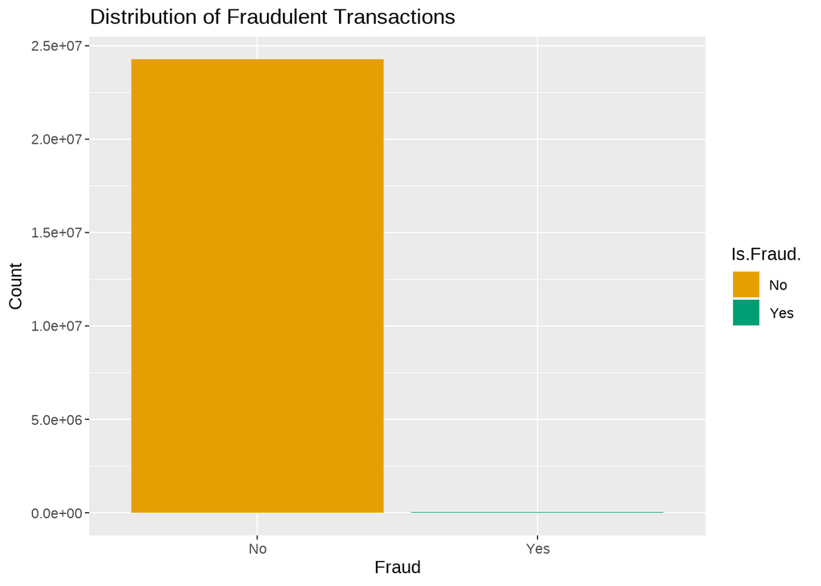

```r
ggplot(data = data_cleaned, aes(x = Is.Fraud., fill = Is.Fraud.)) +
  geom_bar() +
  labs(title = "Distribution of Fraudulent Transactions", x = "Fraud", y = "Count")
```

Imbalanced class distribution, where one class significantly outnumbers the other, is a common challenge in classification tasks. In scenarios like fraud detection, the occurrence of rare events (e.g., fraudulent transactions) is far fewer than regular instances. This imbalance poses issues such as biased model training, misleading accuracy, and difficulty in detecting rare events due to a lack of sufficient examples for the minority class.

To address this challenge, a common strategy is to take a sample with proportionate classes. This involves creating a balanced dataset by randomly selecting instances from both classes, ensuring that the model is exposed to an equal representation of each. This approach enhances model performance, as it prevents the model from being skewed towards the majority class and allows it to discern patterns in the minority class.

The benefits of sampling with proportionate classes include improved model generalization, mitigation of bias, better evaluation metrics accuracy, and computational efficiency. Striking the right balance in the sampling proportion is crucial, as too much undersampling may lead to information loss. The chosen proportion depends on the specific characteristics of the problem and the desired trade-off between class balance and training set size. This strategy contributes to the development of more robust and equitable machine learning models, particularly in situations where class imbalances are pronounced.

**Test Set**

When balancing classes, it’s crucial to apply the technique to the training set only. The test set should remain representative of the real-world distribution to provide a reliable assessment of model generalization. Introducing class balancing to the test set could distort the evaluation metrics, leading to an inaccurate estimation of model performance.

**Strategy**

We are following a strategy to handle both the imbalanced class issue and the computational challenges posed by a large dataset. Here’s a step-by-step breakdown of the plan:

The **downSample** function calculates the frequency of each class in the target variable. Then it randomly selects a subset of instances from the majority class to achieve the desired downsampling rate. Create Balanced Dataset:

```r
# Assuming 'original_data' is your original dataset
set.seed(123)  # Set seed for reproducibility

# Step 1: Split original dataset
splitIndex <- createDataPartition(data_cleaned$Is.Fraud., p = 0.7, list = FALSE)
train_set <- data_cleaned[splitIndex, ]
test_set <- data_cleaned[-splitIndex, ]


fwrite(train_set, "train_data_cleaned.csv")
fwrite(test_set, "test_data_cleaned.csv")
```

```r
train_set <- read.csv("train_data_cleaned.csv")
test_set <- read.csv("test_data_cleaned.csv")


train_set$Is.Fraud. = factor(x = train_set$Is.Fraud.)
# Step 2: Balance the training set ( using undersampling)
set.seed(456)
balanced_train_set <- downSample(x = train_set[, -which(names(train_set) == "Is.Fraud.")],
                                 y = train_set$Is.Fraud.)


# Shuffle the rows to mix the classes
balanced_train_set <- balanced_train_set[sample(nrow(balanced_train_set)), ]

fwrite(balanced_train_set, "balanced_train_set_data_cleaned.csv")

set.seed(831)
# Step 3: Take a sample from the balanced training set
sampled_train_set <- balanced_train_set[sample(nrow(balanced_train_set), 0.25 * nrow(balanced_train_set)), ]


# Step 4: Sample the test set proportionally
sampled_test_set <- test_set[sample(nrow(test_set), 0.3 * nrow(sampled_train_set)), ]

# Now 'sampled_train_set' and 'sampled_test_set' can be used for model training and testing
```

```r
# Check the class distribution in the original, training, and test sets
table(sampled_train_set$Class)
```

```
##
##   No  Yes
## 5239 5174
```

```r
table(sampled_test_set$Is.Fraud.)
```

```
##
##   No  Yes
## 3118    5
```

## 3.5 Fix or remove typos or errors

```r
glimpse(sampled_train_set)
```

```
## Rows: 10,413
## Columns: 36
## $ User                        <int> 1338, 958, 1933, 924, 359, 212, 1271, 1785…
## $ Card                        <int> 5, 0, 1, 2, 1, 0, 1, 1, 0, 0, 4, 0, 5, 3, …
## $ Year                        <int> 2018, 2010, 2019, 2009, 2004, 2017, 2008, …
## $ Month                       <int> 10, 5, 4, 12, 3, 12, 12, 11, 9, 9, 12, 12,…
## $ Day                         <int> 12, 18, 22, 5, 8, 3, 25, 21, 7, 16, 5, 21,…
## $ Time                        <chr> "06:01", "16:15", "13:23", "15:26", "02:20…
## $ Amount                      <chr> "$28.74", "$139.88", "$104.15", "$34.08", …
## $ Use.Chip                    <chr> "Online Transaction", "Swipe Transaction",…
## $ Merchant.Name               <dbl> -2.088492e+18, -3.895049e+18, 1.913477e+18…
## $ Merchant.City               <chr> "ONLINE", "Scarborough", "Parkers Prairie"…
## $ Merchant.State              <chr> "", "ME", "MN", "SC", "", "Italy", "", "CA…
## $ Zip                         <int> NA, 4074, 56361, 29654, NA, NA, NA, 94606,…
## $ MCC                         <int> 4784, 4900, 5300, 5813, 4722, 5411, 5311, …
```

[output cut: 23 more lines]

First, it is important to set appropriate column names.

```r
new_column_names_training <- c( "User_id", "Card_id", "Year", "Month", "Day", "Time", "Amount", "Use_Chip", "Merchant_Name", "Merchant_City", "Merchant_State", "Zip", "MCC",  "Errors",   "Person" , "Current_Age", "Retirement_Age", "Birth_Year", "Birth_Month", "Gender", "Address", "Apartment", "City", "State", "Zipcode", "Latitude", "Longitude", "Per_Capita_Income_Zipcode", "Yearly_Income_Person",     "Total_Debt", "FICO_Score", "Num_Credit_Cards", "Card_Type","Credit_Limit", "Card_on_Dark_Web","Fraud")

new_column_names_test <- c( "User_id", "Card_id", "Year", "Month", "Day", "Time", "Amount", "Use_Chip", "Merchant_Name", "Merchant_City", "Merchant_State", "Zip", "MCC",  "Errors", "Fraud",  "Person" , "Current_Age", "Retirement_Age", "Birth_Year", "Birth_Month", "Gender", "Address", "Apartment", "City", "State", "Zipcode", "Latitude", "Longitude", "Per_Capita_Income_Zipcode", "Yearly_Income_Person",     "Total_Debt", "FICO_Score", "Num_Credit_Cards", "Card_Type","Credit_Limit", "Card_on_Dark_Web")

colnames(sampled_train_set) <- new_column_names_training
colnames(sampled_test_set) <- new_column_names_test
```

### 3.5.1 Encoding Categorical Variables

It is essential to encode categorical variables as most machine learning algorithms require numerical data for analysis. Encoding ensures that the model can interpret and learn from categorical features.

Furthermore, assigning meaningful labels to levels makes it easier to understand the categories represented by each level.

Use.Chip column contains different transaction methods.

```r
### Use_Chip
sampled_train_set$Use_Chip= factor(x = sampled_train_set$Use_Chip,
                                  levels = c("Chip Transaction", "Swipe Transaction", "Online Transaction"),
                                  labels =  c("Chip", "Swipe", "Online")
                                  )

sampled_test_set$Use_Chip= factor(x = sampled_test_set$Use_Chip,
                                  levels = c("Chip Transaction", "Swipe Transaction", "Online Transaction"),
                                  labels =  c("Chip", "Swipe", "Online")
                                  )


### Card_Type
sampled_train_set$Card_Type = factor(x = sampled_train_set$Card_Type,
                                    levels = c("Debit", "Credit"),
                                   labels = c("Debit", "Credit")
                                   )

sampled_test_set$Card_Type = factor(x = sampled_test_set$Card_Type,
                                    levels = c("Debit", "Credit"),
                                   labels = c("Debit", "Credit")
                                   )


### Card_on_Dark_Web
sampled_train_set$Card_on_Dark_Web = factor(x = sampled_train_set$Card_on_Dark_Web,
                                          levels = c("No", "Yes"),
                                          labels = c("No", "Yes")
                                          )

sampled_test_set$Card_on_Dark_Web = factor(x = sampled_test_set$Card_on_Dark_Web,
                                          levels = c("No", "Yes"),
                                          labels = c("No", "Yes")
                                          )


### Gender
sampled_train_set$Gender = factor(x = sampled_train_set$Gender,
                                levels = c("Female", "Male"),
                                labels = c("Female", "Male") )

sampled_test_set$Gender = factor(x = sampled_test_set$Gender,
                                levels = c("Female", "Male"),
                                labels = c("Female", "Male") )


### Fraud
sampled_train_set$Fraud = factor(x = sampled_train_set$Fraud)
sampled_test_set$Fraud = factor(x = sampled_test_set$Fraud)

### Merchant_City
sampled_train_set$Merchant_City = as.factor(sampled_train_set$Merchant_City)
sampled_test_set$Merchant_City = as.factor(sampled_test_set$Merchant_City)

### Merchant_State
sampled_train_set$Merchant_State = as.factor(sampled_train_set$Merchant_State)
sampled_test_set$Merchant_State = as.factor(sampled_test_set$Merchant_State)

### City
sampled_train_set$City = as.factor(sampled_train_set$City)
sampled_test_set$City = as.factor(sampled_test_set$City)

### State
sampled_train_set$State = as.factor(sampled_train_set$State)
sampled_test_set$State = as.factor(sampled_test_set$State)
```

### 3.5.2 Fix numerical variables

Remove the dollar sign ($) and convert the following columns to numeric types

```r
# The gsub function is used for pattern matching and replacement in strings. \\$ is a regular expression pattern that matches the dollar  # sign $. The double backslash is used to escape the special meaning of the dollar sign in regular expressions.
# An empty string "" is specified as the replacement

sampled_train_set$Amount <- as.numeric(gsub("\\$", "", sampled_train_set$Amount))
sampled_test_set$Amount <- as.numeric(gsub("\\$", "", sampled_test_set$Amount))

sampled_train_set$Credit_Limit <- as.numeric(gsub("\\$", "", sampled_train_set$Credit_Limit))
sampled_test_set$Credit_Limit <- as.numeric(gsub("\\$", "", sampled_test_set$Credit_Limit))

sampled_train_set$Yearly_Income_Person <- as.numeric(gsub("\\$", "", sampled_train_set$Yearly_Income_Person))
sampled_test_set$Yearly_Income_Person <- as.numeric(gsub("\\$", "", sampled_test_set$Yearly_Income_Person))

sampled_train_set$Per_Capita_Income_Zipcode <- as.numeric(gsub("\\$", "", sampled_train_set$Per_Capita_Income_Zipcode))
sampled_test_set$Per_Capita_Income_Zipcode <- as.numeric(gsub("\\$", "", sampled_test_set$Per_Capita_Income_Zipcode))

sampled_train_set$Total_Debt <- as.numeric(gsub("\\$", "", sampled_train_set$Total_Debt))
sampled_test_set$Total_Debt <- as.numeric(gsub("\\$", "", sampled_test_set$Total_Debt))
```

### 3.5.3 Change date format

```r
# Convert Time column to POSIXct format
sampled_train_set$Time <- as.POSIXct(sampled_train_set$Time, format = "%H:%M", tz = "UTC")
sampled_test_set$Time <- as.POSIXct(sampled_test_set$Time, format = "%H:%M", tz = "UTC")

# Assuming that Year, Month, and Day are already numeric
sampled_train_set$Date <- as.Date(paste(sampled_train_set$Year, sampled_train_set$Month, sampled_train_set$Day, sep = "-"))
sampled_test_set$Date <- as.Date(paste(sampled_test_set$Year, sampled_test_set$Month, sampled_test_set$Day, sep = "-"))
```

```r
glimpse(sampled_train_set)
```

```
## Rows: 10,413
## Columns: 37
## $ User_id                   <int> 1338, 958, 1933, 924, 359, 212, 1271, 1785, …
## $ Card_id                   <int> 5, 0, 1, 2, 1, 0, 1, 1, 0, 0, 4, 0, 5, 3, 3,…
## $ Year                      <int> 2018, 2010, 2019, 2009, 2004, 2017, 2008, 20…
## $ Month                     <int> 10, 5, 4, 12, 3, 12, 12, 11, 9, 9, 12, 12, 2…
## $ Day                       <int> 12, 18, 22, 5, 8, 3, 25, 21, 7, 16, 5, 21, 3…
## $ Time                      <dttm> 2023-12-24 06:01:00, 2023-12-24 16:15:00, 2…
## $ Amount                    <dbl> 28.74, 139.88, 104.15, 34.08, 351.00, 5.70, …
## $ Use_Chip                  <fct> Online, Swipe, Swipe, Swipe, Online, Chip, O…
## $ Merchant_Name             <dbl> -2.088492e+18, -3.895049e+18, 1.913477e+18, …
## $ Merchant_City             <fct> ONLINE, Scarborough, Parkers Prairie, Honea …
## $ Merchant_State            <fct> , ME, MN, SC, , Italy, , CA, Italy, OH, , FL…
## $ Zip                       <int> NA, 4074, 56361, 29654, NA, NA, NA, 94606, N…
## $ MCC                       <int> 4784, 4900, 5300, 5813, 4722, 5411, 5311, 35…
```

[output cut: 24 more lines]

```r
summary(sampled_train_set)
```

```
##     User_id        Card_id           Year          Month             Day
##  Min.   :   0   Min.   :0.000   Min.   :1991   Min.   : 1.000   Min.   : 1.00
##  1st Qu.: 549   1st Qu.:0.000   1st Qu.:2008   1st Qu.: 4.000   1st Qu.: 8.00
##  Median :1019   Median :1.000   Median :2012   Median : 7.000   Median :16.00
##  Mean   :1018   Mean   :1.492   Mean   :2012   Mean   : 6.627   Mean   :15.74
##  3rd Qu.:1495   3rd Qu.:2.000   3rd Qu.:2016   3rd Qu.:10.000   3rd Qu.:23.00
##  Max.   :1998   Max.   :8.000   Max.   :2020   Max.   :12.000   Max.   :31.00
##
##       Time                            Amount          Use_Chip
##  Min.   :2023-12-24 00:00:00.00   Min.   :-500.00   Chip  :2177
##  1st Qu.:2023-12-24 09:25:00.00   1st Qu.:  11.72   Swipe :4469
##  Median :2023-12-24 12:22:00.00   Median :  44.61   Online:3767
##  Mean   :2023-12-24 12:31:35.83   Mean   :  76.53
##  3rd Qu.:2023-12-24 15:36:00.00   3rd Qu.: 100.00
##  Max.   :2023-12-24 23:59:00.00   Max.   :4133.28
##
##  Merchant_Name               Merchant_City  Merchant_State      Zip
##  Min.   :-9.199e+18   ONLINE        :3768          :3768   Min.   : 1020
##  1st Qu.:-4.282e+18   Rome          : 811   Italy  : 810   1st Qu.:28602
##  Median :-2.452e+17   Algiers       : 128   CA     : 705   Median :46405
##  Mean   :-1.779e+17   Port au Prince:  69   TX     : 431   Mean   :51231
##  3rd Qu.: 3.781e+18   Strasburg     :  62   NY     : 385   3rd Qu.:77586
##  Max.   : 9.223e+18   Mexico City   :  53   FL     : 331   Max.   :99508
##                       (Other)       :5522   (Other):3983   NA's   :4951
##       MCC          Errors             Person           Current_Age
##  Min.   :1711   Length:10413       Length:10413       Min.   : 18.00
##  1st Qu.:5094   Class :character   Class :character   1st Qu.: 43.00
##  Median :5411   Mode  :character   Mode  :character   Median : 53.00
##  Mean   :5401                                         Mean   : 55.08
##  3rd Qu.:5812                                         3rd Qu.: 65.00
##  Max.   :9402                                         Max.   :101.00
##
##  Retirement_Age    Birth_Year    Birth_Month       Gender
##  Min.   :50.00   Min.   :1918   Min.   : 1.00   Female:5422
##  1st Qu.:65.00   1st Qu.:1955   1st Qu.: 3.00   Male  :4991
##  Median :66.00   Median :1967   Median : 7.00
##  Mean   :66.44   Mean   :1964   Mean   : 6.59
##  3rd Qu.:68.00   3rd Qu.:1976   3rd Qu.:10.00
##  Max.   :79.00   Max.   :2002   Max.   :12.00
##
```

[output cut: 17 more lines]

```
##  Min.   :     1       Min.   :     0   Min.   :488.0   Min.   :1.000
##  1st Qu.: 32150       1st Qu.: 16549   1st Qu.:684.0   1st Qu.:3.000
##  Median : 40189       Median : 49681   Median :716.0   Median :4.000
##  Mean   : 45275       Mean   : 56211   Mean   :714.8   Mean   :3.943
##  3rd Qu.: 52754       3rd Qu.: 82822   3rd Qu.:757.0   3rd Qu.:5.000
##  Max.   :280199       Max.   :461854   Max.   :850.0   Max.   :9.000
##
##   Card_Type     Credit_Limit   Card_on_Dark_Web Fraud           Date
##  Debit :8423   Min.   :   18   No :10413        No :5239   Min.   :1991-12-06
##  Credit:1249   1st Qu.:21968   Yes:    0        Yes:5174   1st Qu.:2008-10-02
##  NA's  : 741   Median :24295                               Median :2012-09-20
##                Mean   :23906                               Mean   :2012-05-22
##                3rd Qu.:24295                               3rd Qu.:2016-05-09
##                Max.   :46414                               Max.   :2020-02-28
##
```

```r
fwrite(sampled_train_set, "sampled_train_set.csv")
fwrite(sampled_test_set, "sampled_test_set.csv")
```

## 3.6 Missing Values

Missing values, often denoted as NA (Not Available) or NaN (Not-a-Number), are placeholders used in data to represent the absence of a value or an unknown value for a particular observation or variable. They can have a significant impact on data analysis and modeling.

We can see the distribution of the NAs with the mice package

```r
sum(is.na(sampled_train_set))
```

```
## [1] 13383
```

```r
sum(is.na(sampled_test_set))
```

```
## [1] 2821
```

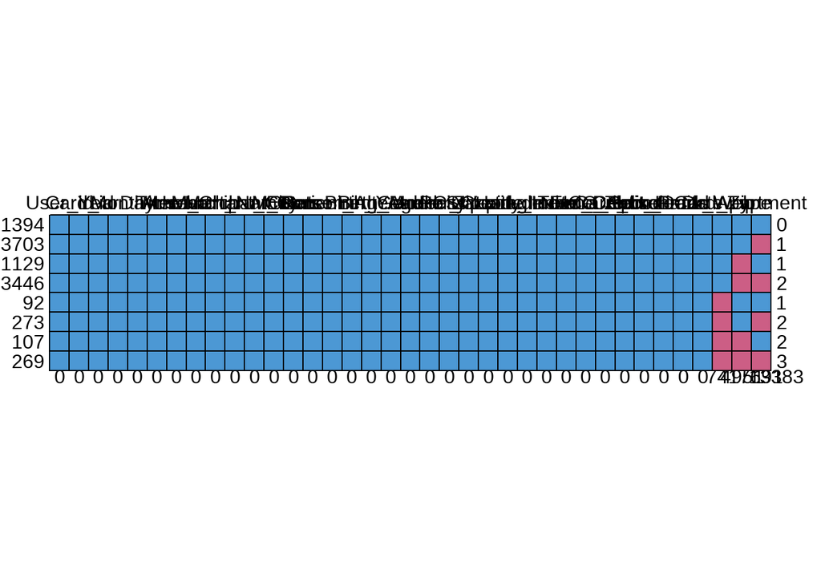

```
##      User_id Card_id Year Month Day Time Amount Use_Chip Merchant_Name
## 1394       1       1    1     1   1    1      1        1             1
## 3703       1       1    1     1   1    1      1        1             1
## 1129       1       1    1     1   1    1      1        1             1
## 3446       1       1    1     1   1    1      1        1             1
## 92         1       1    1     1   1    1      1        1             1
## 273        1       1    1     1   1    1      1        1             1
## 107        1       1    1     1   1    1      1        1             1
## 269        1       1    1     1   1    1      1        1             1
##            0       0    0     0   0    0      0        0             0
##      Merchant_City Merchant_State MCC Errors Person Current_Age Retirement_Age
## 1394             1              1   1      1      1           1              1
## 3703             1              1   1      1      1           1              1
## 1129             1              1   1      1      1           1              1
## 3446             1              1   1      1      1           1              1
```

[output cut: 45 more lines]

```r
md.pattern(sampled_train_set)
```

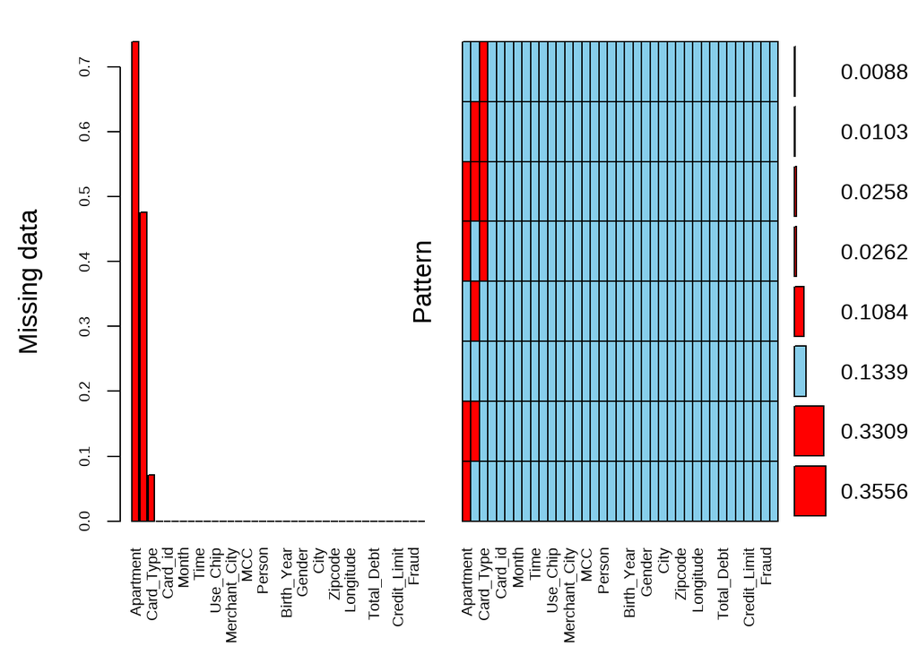

```
##
##  Variables sorted by number of missings:
##                   Variable      Count
##                  Apartment 0.73859599
##                        Zip 0.47546336
##                  Card_Type 0.07116105
##                    User_id 0.00000000
##                    Card_id 0.00000000
##                       Year 0.00000000
##                      Month 0.00000000
##                        Day 0.00000000
##                       Time 0.00000000
##                     Amount 0.00000000
##                   Use_Chip 0.00000000
##              Merchant_Name 0.00000000
##              Merchant_City 0.00000000
##             Merchant_State 0.00000000
##                        MCC 0.00000000
##                     Errors 0.00000000
##                     Person 0.00000000
##                Current_Age 0.00000000
##             Retirement_Age 0.00000000
##                 Birth_Year 0.00000000
##                Birth_Month 0.00000000
##                     Gender 0.00000000
##                    Address 0.00000000
##                       City 0.00000000
##                      State 0.00000000
##                    Zipcode 0.00000000
##                   Latitude 0.00000000
##                  Longitude 0.00000000
##  Per_Capita_Income_Zipcode 0.00000000
##       Yearly_Income_Person 0.00000000
##                 Total_Debt 0.00000000
##                 FICO_Score 0.00000000
##           Num_Credit_Cards 0.00000000
##               Credit_Limit 0.00000000
##           Card_on_Dark_Web 0.00000000
##                      Fraud 0.00000000
##                       Date 0.00000000
```

```r
aggr(sampled_train_set, number = TRUE, sortVars = TRUE, labels = names(sampled_train_set),
     cex.axis = .7, gap = 1, ylab= c('Missing data','Pattern'))
```

It can be seen that the “Apartment” variable has more than 70% of its values as NAs, so it will be removed, as it also does not give to much information. We will also remove “Zip” variable for the same reason.

We also remove the “Errors” variable as almost all its values are empty strings, ““.

```r
sampled_train_set =  sampled_train_set %>% dplyr::select(-Apartment, -Zip, -Errors)
sampled_test_set =  sampled_test_set %>% dplyr::select(-Apartment, -Zip, -Errors)
```

imp_train <- mice(sampled_train_set, method = ‘cart’, m = 4, parallel = TRUE) sampled_train_set= complete(imp_train)

Because of my system doesn’t have sufficient memory (RAM) available to perform the imputation, I am going to remove the observations with missing values considering that I have a high number of observations. However, this is not the best approach.

Let’ see the nº of observations with missing values

```r
sum(apply(sampled_train_set, 1, function(row) any(is.na(row))))
```

```
## [1] 741
```

```r
sum(apply(sampled_test_set, 1, function(row) any(is.na(row))))
```

```
## [1] 180
```

```r
# Remove observations with missing values from sampled_train_set
sampled_train_set <- na.omit(sampled_train_set)

# Remove observations with missing values from sampled_test_set
sampled_test_set <- na.omit(sampled_test_set)
```

```r
sum(is.na(sampled_train_set))
```

```
## [1] 0
```

```r
sum(is.na(sampled_test_set))
```

```
## [1] 0
```

Now, we don’t have any missing values.

```r
fwrite(sampled_train_set, "sampled_train_set_no_NAs.csv")
fwrite(sampled_test_set, "sampled_test_set_no_NAs.csv")
```

## 3.7 Outliers

An outlier is an observation or data point that significantly differs from other observations in a dataset. It is an unusual or rare value that falls outside the typical range of values in a dataset.

First, we make a general boxplot for the entire dataset.

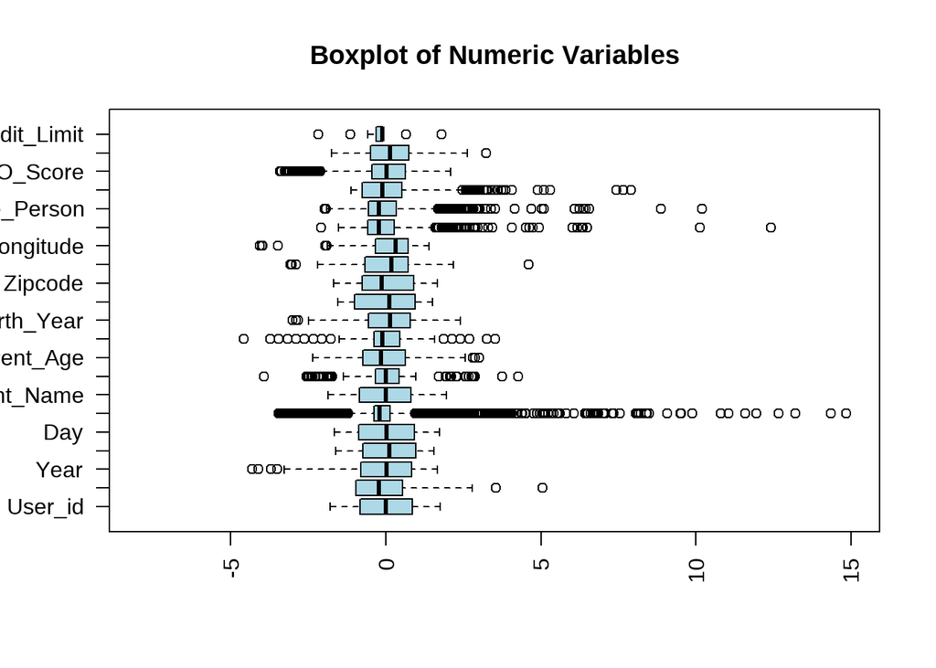

```r
# Select numeric columns only
numeric_data <- sampled_train_set[sapply(sampled_train_set, is.numeric)]

# Create horizontal boxplot for numeric columns
boxplot(scale(numeric_data), col = "lightblue", las = 2, horizontal = TRUE, ylim = c(-8, 15))
# Add a title to the plot
title(main = "Boxplot of Numeric Variables")
```

Upon inspecting the boxplot, it appears that potential outliers are present. Notably, variables associated with monetary values, such as “Amount,” exhibit a higher prevalence of outliers. Let’s zoom in on these specific variables and assess whether this observed behavior is plausible.

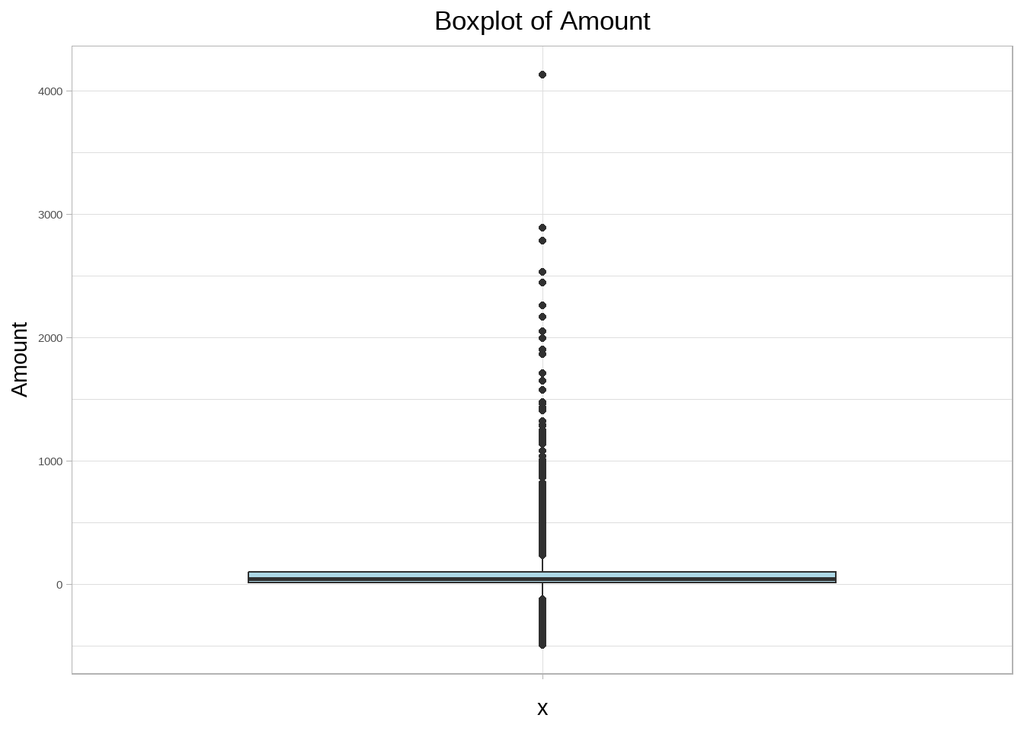

```r
par(mfrow=c(1,3))
# For "Amount"
ggplot(sampled_train_set) +
  aes(x = "", y = Amount) +
  geom_boxplot(fill = "lightblue") +
  labs(y = "Amount") +
  ggtitle("Boxplot of Amount") +  # Add title
  theme_light() +
  theme(plot.title = element_text(hjust = 0.5))  # Center the title
```

In other words, the observed range is plausible in the context of real-world financial transactions, and these values may accurately reflect the diversity of transaction amounts. As a result, it might not be appropriate to consider them as outliers without further domain-specific knowledge.

## 3.8 Visualizations

### 3.8.1 Univariate: Dimension 1

We have already seen the boxplots

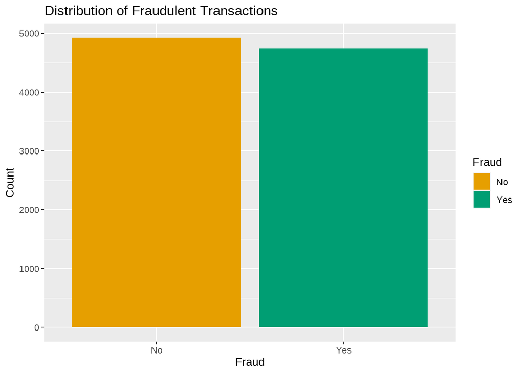

```r
ggplot(data = sampled_train_set, aes(x = Fraud, fill = Fraud)) +
  geom_bar() +
  labs(title = "Distribution of Fraudulent Transactions", x = "Fraud", y = "Count")
```

We can see that know we have balanced classes.

Histogram for Continuous Variables

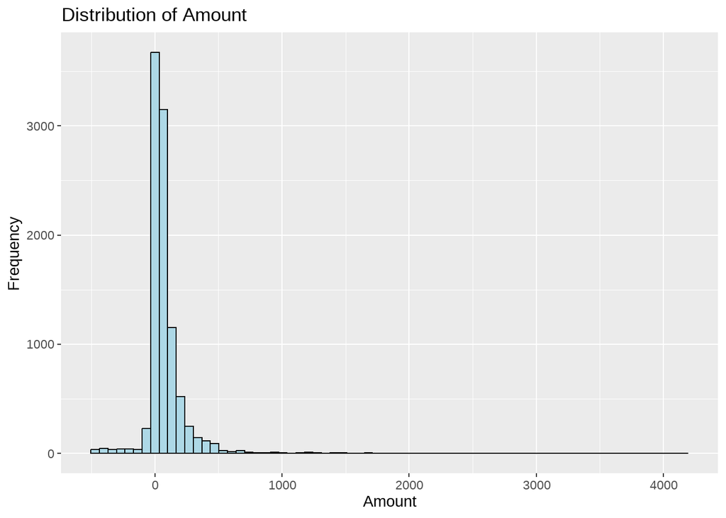

```r
# Example for 'Amount'
library(ggplot2)

ggplot(sampled_train_set, aes(x = Amount)) +
  geom_histogram(fill = "lightblue", color = "black", bins = 70) +
  labs(title = "Distribution of Amount", x = "Amount", y = "Frequency")
```

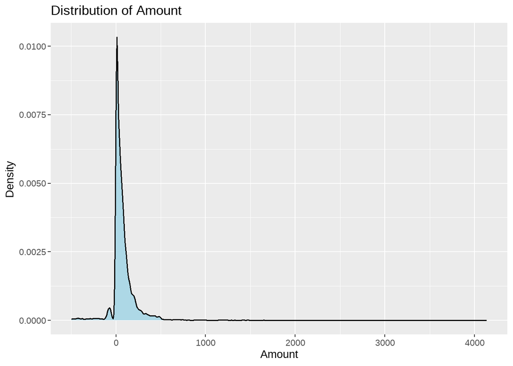

```r
ggplot(sampled_train_set, aes(x = Amount  )) +
  geom_density(fill = "lightblue", color = "black", size = 0.7, linetype =1) +
  #geom_rug(position = "identity", sides = "b", alpha = 0.5) +
  labs(title = "Distribution of Amount", x = "Amount", y = "Density")
```

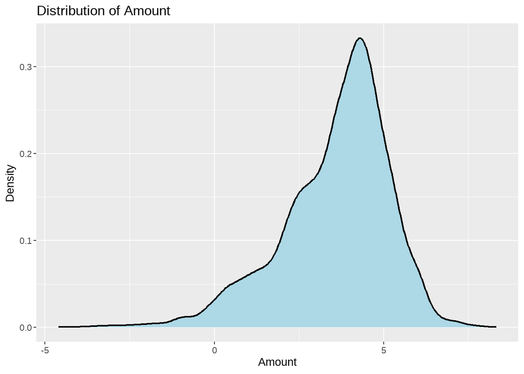

```r
ggplot(sampled_train_set, aes(x = log(Amount)  )) +
  geom_density(fill = "lightblue", color = "black", size = 0.8, linetype =1) +
  #geom_rug(position = "identity", sides = "b", alpha = 0.5) +
  labs(title = "Distribution of Amount", x = "Amount", y = "Density")
```

### 3.8.2 Bivariate

As we know the current age, we don’t need the other variables related with the Age “Birth_Year”, “Birth_Month”, “Retirement_Age”

```r
sampled_train_set =  sampled_train_set %>% dplyr::select(-Birth_Year, -Birth_Month, -Retirement_Age)
sampled_test_set =  sampled_test_set %>% dplyr::select(-Birth_Year, -Birth_Month, -Retirement_Age)
```

**Correlation of numerical variables** It can be seen the relationship between the numerical variables

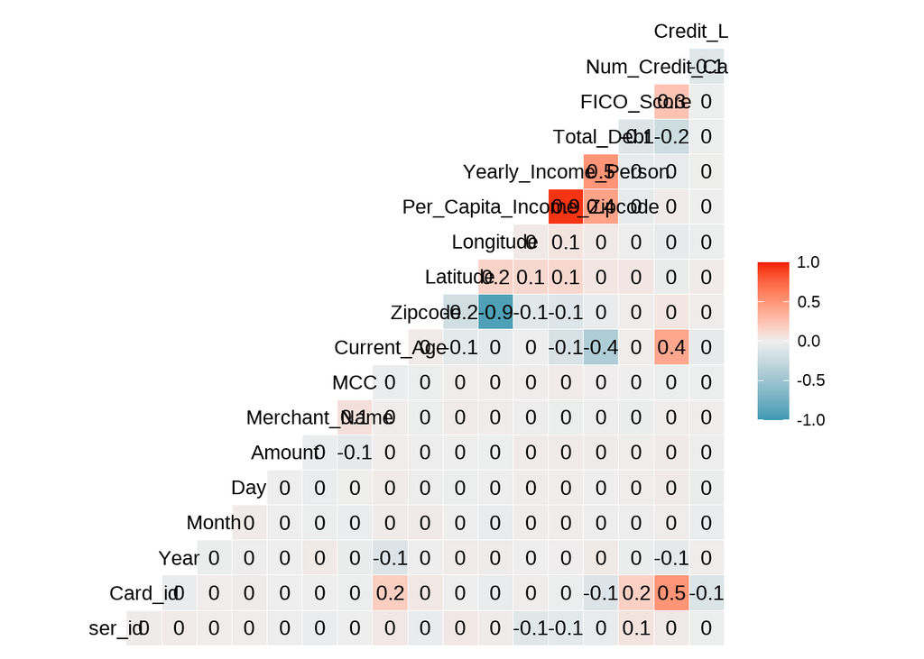

```r
numeric_data <- sampled_train_set[sapply(sampled_train_set, is.numeric)]

ggcorr(numeric_data, label = T)
```

```r
# Assuming 'sampled_train_set' is your sampled training set

correlation_matrix <- cor(numeric_data)

# Print the correlation matrix
print(correlation_matrix)
```

```
##                                 User_id       Card_id         Year
## User_id                    1.0000000000  0.0163555932  0.020351562
## Card_id                    0.0163555932  1.0000000000 -0.029526918
## Year                       0.0203515617 -0.0295269176  1.000000000
## Month                      0.0072948087  0.0114618895 -0.016871332
## Day                        0.0069546180  0.0158002105 -0.008518663
## Amount                     0.0039633354 -0.0012767257 -0.001148205
## Merchant_Name             -0.0180217468 -0.0005250306  0.031824043
## MCC                        0.0004984689 -0.0156698280 -0.026397522
## Current_Age                0.0383060403  0.1866166465 -0.114164976
## Zipcode                   -0.0318504309  0.0389548180 -0.002727487
## Latitude                   0.0339026444 -0.0004595777  0.022785491
## Longitude                  0.0171772687 -0.0333255872  0.016874282
## Per_Capita_Income_Zipcode -0.0833095907  0.0116738830  0.001235972
## Yearly_Income_Person      -0.0697527679 -0.0122200843  0.005855389
## Total_Debt                -0.0397440601 -0.1122481587  0.030943975
## FICO_Score                 0.0659241765  0.1736306630 -0.017202600
## Num_Credit_Cards           0.0284335850  0.5120858971 -0.056531676
## Credit_Limit              -0.0101032985 -0.1252071290  0.012586440
##                                   Month           Day        Amount
## User_id                    0.0072948087  0.0069546180  0.0039633354
## Card_id                    0.0114618895  0.0158002105 -0.0012767257
## Year                      -0.0168713316 -0.0085186630 -0.0011482053
## Month                      1.0000000000  0.0202456237 -0.0002091009
## Day                        0.0202456237  1.0000000000 -0.0015690645
## Amount                    -0.0002091009 -0.0015690645  1.0000000000
## Merchant_Name             -0.0114041252 -0.0220920025 -0.0208881732
## MCC                       -0.0179531511  0.0024505961 -0.0561109487
## Current_Age                0.0248323090  0.0233384319  0.0110702640
## Zipcode                    0.0270092720 -0.0068881846  0.0044152765
## Latitude                  -0.0021380968 -0.0148396661  0.0005855749
## Longitude                 -0.0336869523 -0.0003793235 -0.0055126739
## Per_Capita_Income_Zipcode  0.0090603184  0.0120276636  0.0194844580
## Yearly_Income_Person       0.0072581759  0.0110148150  0.0221561477
## Total_Debt                 0.0037476592 -0.0004693306  0.0165396368
## FICO_Score                -0.0072206699  0.0115029907  0.0136568263
## Num_Credit_Cards           0.0139439394  0.0279060307  0.0261355903
## Credit_Limit              -0.0185656581 -0.0174376716  0.0040983665
##                           Merchant_Name           MCC   Current_Age
## User_id                   -0.0180217468  0.0004984689  0.0383060403
```

[output cut: 78 more lines]

```
## Month                     -0.0185656581
## Day                       -0.0174376716
## Amount                     0.0040983665
## Merchant_Name              0.0115426721
## MCC                       -0.0116399759
## Current_Age               -0.0446892651
## Zipcode                    0.0134337255
## Latitude                   0.0202048550
## Longitude                 -0.0114606049
## Per_Capita_Income_Zipcode -0.0002781096
## Yearly_Income_Person       0.0024715045
## Total_Debt                -0.0042896360
## FICO_Score                -0.0035052040
## Num_Credit_Cards          -0.0936957263
## Credit_Limit               1.0000000000
```

In this case, the correlation coefficient between Yearly_Income_Person and Per_Capita_Income_Zipcode is approximately 0.93. In practical terms, this high positive correlation suggests that areas with higher per capita income tend to have residents with higher yearly individual incomes. It’s not surprising, as per capita income is calculated by dividing the total income of an area by its population, and areas with higher individual incomes are likely to contribute to a higher per capita income.

This strong relationship could lead to multicollinearity, making it challenging to interpret the individual contributions of each variable. However, While a high correlation suggests a strong statistical association, it doesn’t imply causation. Other factors or variables may contribute to this relationship.

Total_Debt and Yearly_Income_Person: These variables show a moderate positive correlation, suggesting that as yearly income increases, total debt tends to increase as well.

Current_Age and Num_Credit_Cards: There is a positive correlation between the current age of the person and the number of credit cards they have.

FICO_Score and Total_Debt: There is a negative correlation between FICO score and total debt, suggesting that individuals with higher FICO scores tend to have lower total debt.

**Distribution on amount depending on Fraud Class**

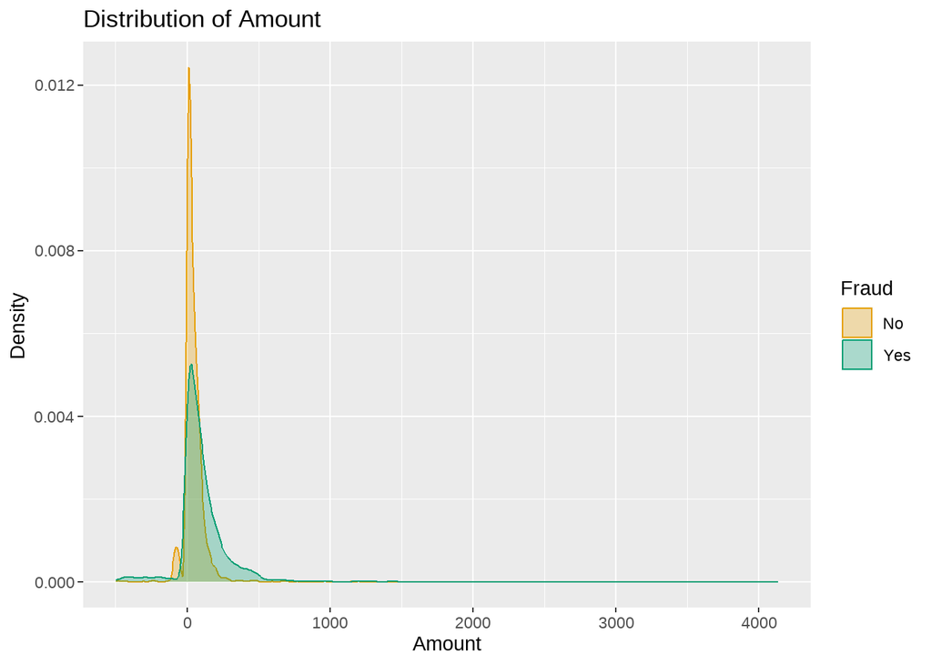

```r
ggplot(data=sampled_train_set, aes(x=Amount)) +
    geom_density(aes(group=Fraud, colour=Fraud, fill=Fraud), adjust=1.5, alpha=0.3)  +
  labs(title = "Distribution of Amount", x = "Amount", y = "Density")
```

```r
    #theme_ipsum()
```

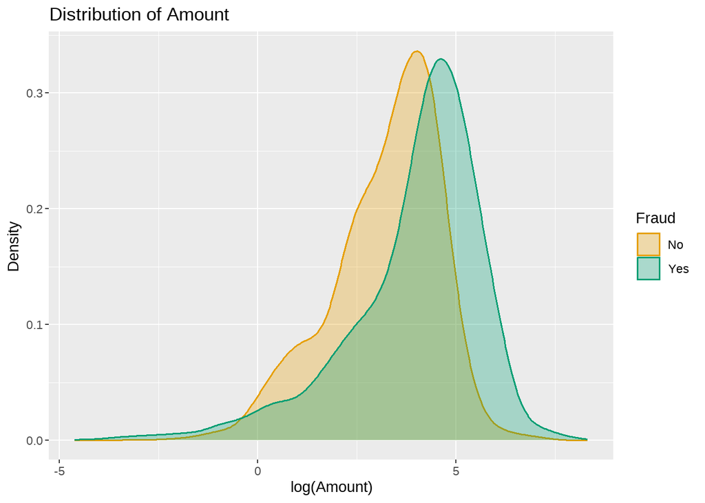

```r
ggplot(data=sampled_train_set, aes(x=log(Amount) )) +
    geom_density(aes(group=Fraud, colour=Fraud, fill=Fraud), adjust=1.5, alpha=0.3, size = 0.6, linetype =1) +
    labs(title = "Distribution of Amount", x = "log(Amount)", y = "Density")
```

```r
    #theme_ipsum()
```

It seems that the transactions with ‘LogAmount’ larger than 4.5 (90 dollars) and smaller than -0.5 (0.6 dollars) have a higher frequency and probability density of being fraudulent. On the other hand, the ones with ‘LogAmount’ from -0.5 to 4.5 have a higher chance of being legit.

**Fraudulent Transactions by Card Type**

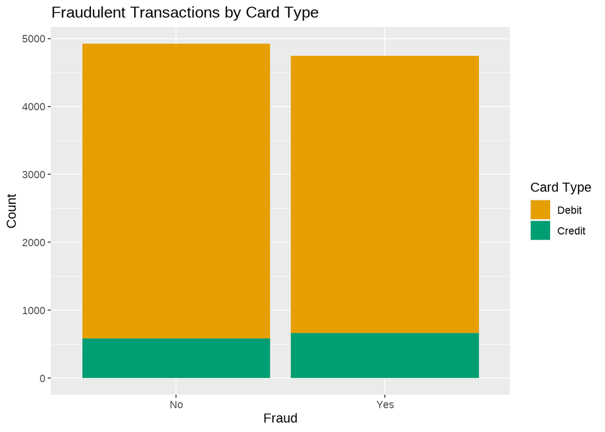

```r
ggplot(data = sampled_train_set, aes(x = Fraud, fill = Card_Type)) +
  geom_bar(position = "stack") +
  labs(title = "Fraudulent Transactions by Card Type", x = "Fraud", y = "Count", fill = "Card Type")
```

The proportion of card types is similar for both types of transactions, and most transactions, regardless of fraud status, are made with debit cards. This suggests that the distribution of card types might not be a differentiating factor for fraud detection in this dataset.

**Fraudulent Transactions by Age Group**

Discretizing age and creating a graph between fraud and age groups could be a useful approach. It might help identify if certain age groups are more susceptible to fraud or if there are patterns in fraudulent activities based on age.

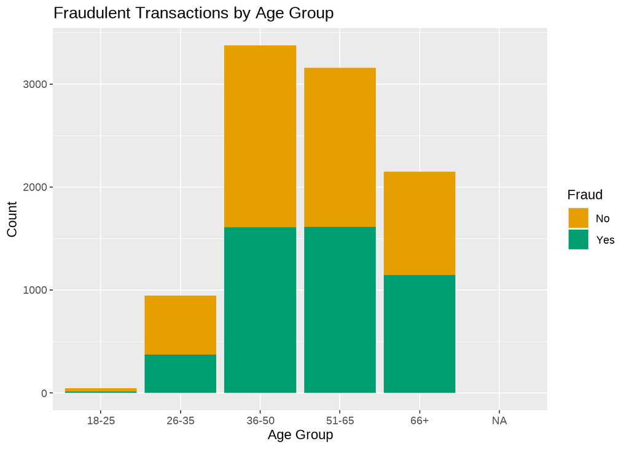

```r
# Assuming you have a variable 'Age' in your dataset

# Create age groups
sampled_train_set$Age_Group <- cut(sampled_train_set$Current_Age, breaks = c(18, 25, 35, 50, 65, max(sampled_train_set$Current_Age)), labels = c("18-25", "26-35", "36-50", "51-65", "66+"))

sampled_test_set$Age_Group <- cut(sampled_test_set$Current_Age, breaks = c(18, 25, 35, 50, 65, max(sampled_test_set$Current_Age)), labels = c("18-25", "26-35", "36-50", "51-65", "66+"))

# Create a bar plot
ggplot(data = sampled_train_set, aes(x = Age_Group, fill = Fraud)) +
  geom_bar(position = "stack") +
  labs(title = "Fraudulent Transactions by Age Group", x = "Age Group", y = "Count", fill = "Fraud")
```

We can see that in 36-50, 51-65 and 66+ groups there are much more transactions. The amount of fraudulent transaction in this groups represent almost the half of their transactions. In 26-35 group the fraudulent transactions represent a third of their transactions. Finally, in group 18-25 there are not almost fraudulent transactions.

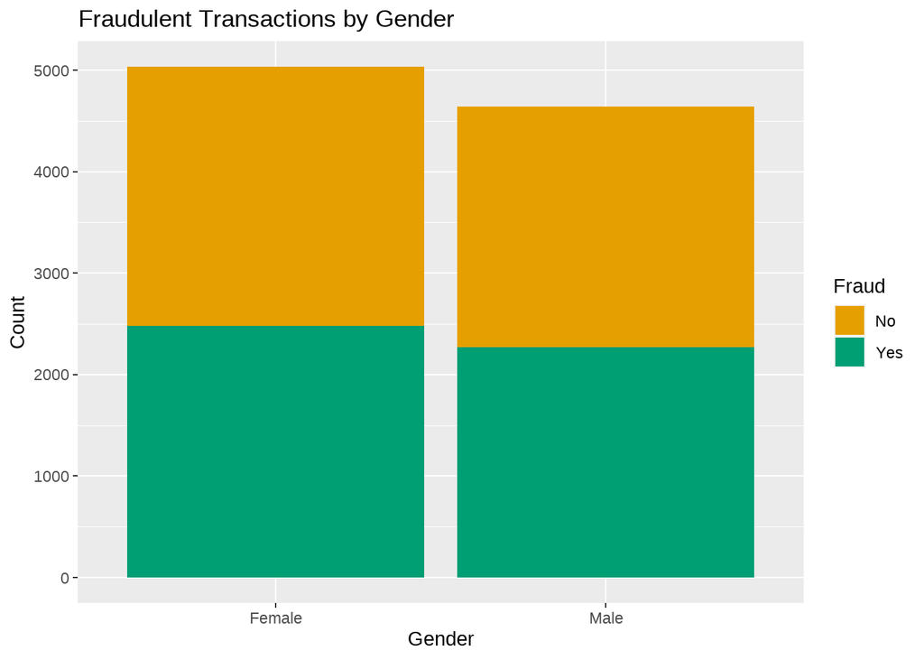

```r
# Create a bar plot
ggplot(data = sampled_train_set, aes(x = Gender, fill = Fraud)) +
  geom_bar(position = "stack") +
  labs(title = "Fraudulent Transactions by Gender", x = "Gender", y = "Count", fill = "Fraud")
```

We can see a similar proportion, although for females it is slightly bigger.

**Transaction Method**

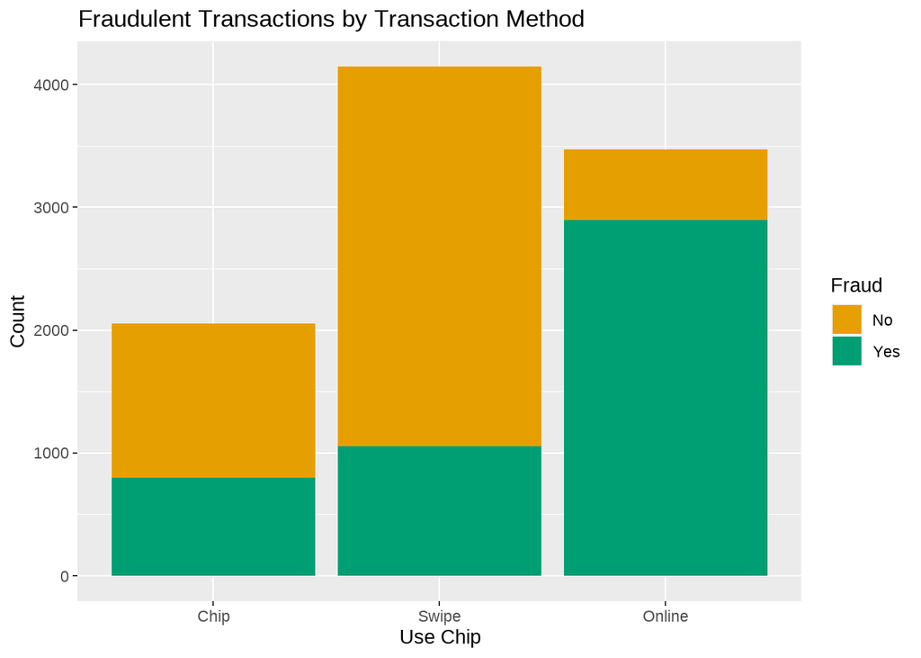

```r
ggplot(data = sampled_train_set, aes(x = Use_Chip, fill = Fraud)) +
  geom_bar(position = "stack") +
  labs(title = "Fraudulent Transactions by Transaction Method", x = "Use Chip", y = "Count", fill = "Fraud")
```

We can see that online transactions present the most significant vulnerability to fraud, as the majority are fraudulent.

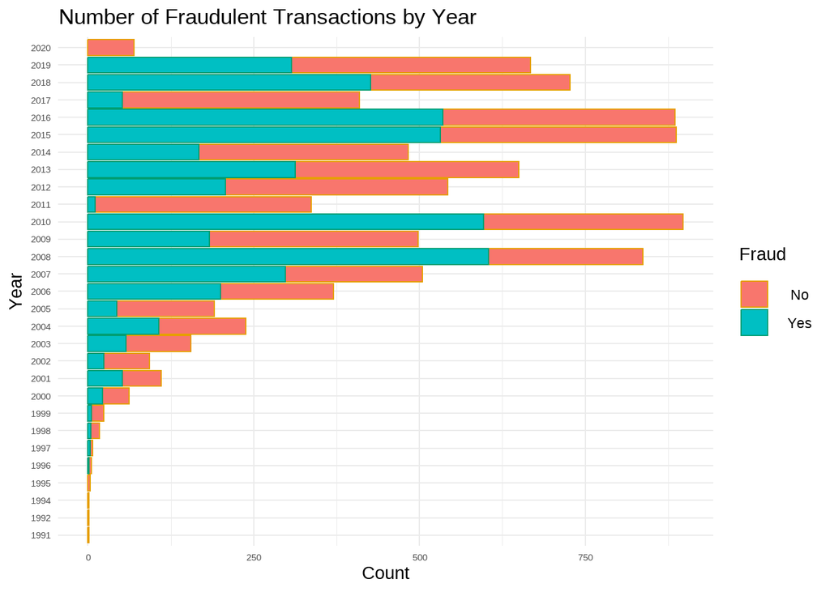

```r
ggplot(data = sampled_train_set, aes(x = as.factor(Year))) +
  geom_bar(aes(y = after_stat(count), fill = Fraud, color = Fraud), stat = "count") +
  labs(title = "Number of Fraudulent Transactions by Year", x = "Year", y = "Count") +
  scale_fill_manual(values = c("#F8766D", "#00BFC3" ), name = "Fraud") +  # Specify fill colors
  #scale_color_manual(values = c("darkred", "darkblue"), name = "Fraud") +  # Specify border colors
  theme_minimal() +
  coord_flip()  # Rotate the plot
```

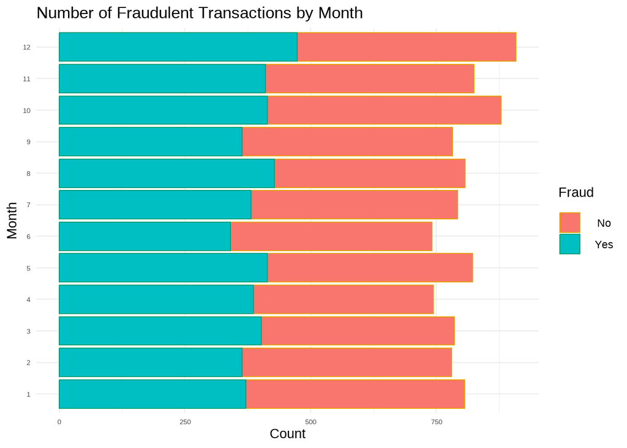

```r
ggplot(data = sampled_train_set, aes(x = as.factor(Month))) +
  geom_bar(aes(y = after_stat(count), fill = Fraud, color = Fraud), stat = "count") +
  labs(title = "Number of Fraudulent Transactions by Month", x = "Month", y = "Count") +
  scale_fill_manual(values = c("#F8766D", "#00BFC3" ), name = "Fraud") +  # Specify fill colors
  #scale_color_manual(values = c("darkred", "darkblue"), name = "Fraud") +  # Specify border colors
  theme_minimal() +
  coord_flip()  # Rotate the plot
```

The distribution of fraud cases across months doesn’t show significant variations. This observation and is indicative that fraudulent activities might not be strongly influenced by the specific month.

## 3.9 Feature Selection

Later there will be used more sophisticated ways for doing this.

Let’s consider variables for potential removal based on various criteria:

1. *Identifiers:* “User_id” and “Card_id” are likely unique identifiers and may not contribute much predictive power to the model. As well as “Person” which corresponds with the name of the person.
2. *Location Information:* “Merchant_Name,” “Address,” “Zipcode,” “Latitude,” and “Longitude” , because they are not relevant. In addition to this, we are going to remove “Merchant_State” as there are too many cells with empty strings “”
3. *“Current_Age”* : As we have already discretize the age and we have “Age_Group”
4. *Date and Time Components:* “Year,” “Month,” “Day,” and “Time” might be redundant if we already have a variable like “Date” that captures this information.
5. *“Card_on_Dark_Web”*: As all its values are “No”, it does not provide any information.
6. *“MCC” (Merchant Category Code):* Remove it as there are too many codes.

```r
sampled_train_set =  sampled_train_set %>% dplyr::select(-User_id, -Card_id, -Person, -Merchant_Name, -Address, -Zipcode, -Latitude, -Longitude, -Merchant_State,- Current_Age, -Year, -Month, -Day, -Time, -Card_on_Dark_Web, -MCC)

sampled_test_set =   sampled_test_set %>% dplyr::select(-User_id, -Card_id, -Person, -Merchant_Name, -Address, -Zipcode, -Latitude, -Longitude, -Merchant_State,- Current_Age, -Year, -Month, -Day, -Time, -Card_on_Dark_Web, -MCC)
```

```r
fwrite(sampled_train_set, "sampled_train_set_class.csv")
fwrite(sampled_test_set, "sampled_test_set_class.csv")
```

```r
sampled_train_set_class <- read.csv("sampled_train_set_class.csv")
sampled_test_set_class <- read.csv("sampled_test_set_class.csv")
```

This project began with 36 variables, and know it has 16.

# 4 CLASSIFICATION

## 4.1 Statistical Tools for Classification

### 4.1.1 Penalized Logistic Regression

(lab customer analysis)

**Introduction to Logistic Regression**

Penalized logistic regression, specifically implemented through the glmnet package in R, offers several advantages for fraud classification tasks with numerous variables. The regularization techniques, such as Lasso (L1) and Ridge (L2), address challenges associated with high-dimensional datasets, preventing overfitting and improving generalization performance. By automatically selecting relevant variables and stabilizing coefficients, penalized logistic regression enhances the model’s interpretability and efficiency in the presence of multicollinearity. glmnet’s flexibility allows for the fine-tuning of regularization parameters through techniques like cross-validation, enabling the development of a more robust and parsimonious fraud detection model that not only excels in prediction but also provides insights into the underlying patterns contributing to fraudulent activities.

**Applicability in Fraud Classification**

Logistic regression proves to be a valuable tool for fraud classification due to its simplicity, interpretability, and effectiveness in handling binary outcomes. In fraud detection, the goal is to distinguish between legitimate and fraudulent transactions or activities. Logistic regression excels in this context by modeling the probability of an event (fraudulent or not) based on a set of features. The coefficients of the logistic regression model provide insights into the impact of each feature on the likelihood of fraud, facilitating the identification of key factors contributing to fraudulent behavior. Moreover, logistic regression is less prone to overfitting, making it robust with limited data and offering a transparent decision-making process crucial for understanding and validating predictions in sensitive applications like fraud detection.

**Interpretable and Efficient Fraud Detection**

The interpretability of logistic regression enhances its appeal in fraud classification scenarios where explainability is vital. Stakeholders, investigators, and decision-makers can easily comprehend the factors influencing the model’s predictions, fostering trust in the decision-making process. Logistic regression is computationally efficient, making it well-suited for real-time or near-real-time fraud detection systems, where quick and accurate decisions are imperative. Its ability to handle high-dimensional data and adapt to changing circumstances further solidifies logistic regression as a pragmatic choice for fraud classification, providing a balance between simplicity, interpretability, and predictive performance.

The **ctrl configuration** for the caret package’s train function establishes a robust training control structure for implementing penalized logistic regression using techniques like Lasso or Ridge regularization. The choice of 5-fold cross-validation (method = “cv”, number = 5) ensures a thorough evaluation of model performance by repeatedly splitting the dataset into training and testing sets. This aids in mitigating overfitting and provides a more accurate estimate of the model’s effectiveness on unseen data. Additionally, setting classProbs = TRUE enables the generation of class probabilities, a crucial aspect in fraud detection where understanding the likelihood of an event being fraudulent is essential. The verboseIter = TRUE setting facilitates monitoring and reporting the progress of model training iterations, enhancing transparency and aiding in the interpretation of the penalized logistic regression results. This control structure, tailored for your specific project requirements, contributes to the development of a reliable and interpretable fraud detection model.

**lrFit** represents the result of training a penalized logistic regression model using the glmnet algorithm. The logistic regression model predicts the binary outcome variable “Fraud” based on all available predictor variables in the dataset. The model undergoes hyperparameter tuning with a grid search over alpha and lambda values to optimize its performance. Training is conducted on a subset of the dataset (sampled_train_set) with 5-fold cross-validation, enabling robust evaluation. Additionally, the model is assessed using Cohen’s Kappa, a suitable metric for imbalanced classification tasks, and preprocessing involves centering and scaling predictor variables. The resulting lrFit encapsulates a well-tailored logistic regression model for fraud detection, addressing both the complexities of the dataset and the specific requirements of the project.

```r
### Use_Chip
sampled_train_set_class$Use_Chip= factor(x = sampled_train_set_class$Use_Chip,
                                  levels = c("Chip", "Swipe", "Online"),
                                  labels =  c("Chip", "Swipe", "Online")
                                  )

sampled_test_set_class$Use_Chip= factor(x = sampled_test_set_class$Use_Chip,
                                  levels = c("Chip", "Swipe", "Online"),
                                  labels =  c("Chip", "Swipe", "Online")
                                  )


### Card_Type
sampled_train_set_class$Card_Type = factor(x = sampled_train_set_class$Card_Type,
                                    levels = c("Debit", "Credit"),
                                   labels = c("Debit", "Credit")
                                   )

sampled_test_set_class$Card_Type = factor(x = sampled_test_set_class$Card_Type,
                                    levels = c("Debit", "Credit"),
                                   labels = c("Debit", "Credit")
                                   )




### Gender
sampled_train_set_class$Gender = factor(x = sampled_train_set_class$Gender,
                                levels = c("Female", "Male"),
                                labels = c("Female", "Male") )

sampled_test_set_class$Gender = factor(x = sampled_test_set_class$Gender,
                                levels = c("Female", "Male"),
                                labels = c("Female", "Male") )


### Fraud
sampled_train_set_class$Fraud = factor(x = sampled_train_set_class$Fraud)
sampled_test_set_class$Fraud = factor(x = sampled_test_set_class$Fraud)

### Merchant_City
sampled_train_set_class$Merchant_City = as.factor(sampled_train_set_class$Merchant_City)
sampled_test_set_class$Merchant_City = as.factor(sampled_test_set_class$Merchant_City)



### City
sampled_train_set_class$City = as.factor(sampled_train_set_class$City)
sampled_test_set_class$City = as.factor(sampled_test_set_class$City)

### State
sampled_train_set_class$State = as.factor(sampled_train_set_class$State)
sampled_test_set_class$State = as.factor(sampled_test_set_class$State)

# Assuming that Year, Month, and Day are already numeric
sampled_train_set_class$Date <- as.Date(sampled_train_set_class$Date)
sampled_test_set_class$Date <- as.Date(sampled_test_set_class$Date)


sampled_train_set_class$Age_Group = as.factor(sampled_train_set_class$Age_Group)
sampled_test_set_class$Age_Group = as.factor(sampled_test_set_class$Age_Group)
```

```r
sampled_train_set_class =  sampled_train_set_class %>% dplyr::select(-Merchant_City, -City,-State)
sampled_test_set_class =  sampled_test_set_class %>% dplyr::select(-Merchant_City, -City, -State)
```

```r
set.seed(432)
# Assuming you have the levels defined for "Age_Group" in your training set
age_levels <- levels(sampled_train_set_class$Age_Group)

# Ensure the same levels in the test set to avoid errors
sampled_test_set_class$Age_Group <- factor(sampled_test_set_class$Age_Group, levels = age_levels)

ctrl <- trainControl(method = "cv", number = 5,
                     classProbs = TRUE,
                     verboseIter=T)

# Now, you can fit the model and make predictions
lrFit <- train(Fraud ~ .,
               method = "glmnet",
               tuneGrid = expand.grid(alpha = seq(0, 1, 0.1), lambda = seq(0, .1, 0.02)),
               metric = "Kappa",
               data = sampled_train_set_class,
               preProcess = c("center", "scale"),
               trControl = ctrl)
print(lrFit)
```

```
## glmnet
##
## 9672 samples
##   12 predictor
##    2 classes: 'No', 'Yes'
##
## Pre-processing: centered (17), scaled (17)
## Resampling: Cross-Validated (5 fold)
## Summary of sample sizes: 7738, 7737, 7737, 7739, 7737
## Resampling results across tuning parameters:
##
##   alpha  lambda  Accuracy   Kappa
##   0.0    0.00    0.7564101  0.5109184
##   0.0    0.02    0.7564101  0.5109184
##   0.0    0.04    0.7556863  0.5094598
##   0.0    0.06    0.7557895  0.5096512
##   0.0    0.08    0.7551689  0.5084087
##   0.0    0.10    0.7543416  0.5067660
##   0.1    0.00    0.7565129  0.5111451
##   0.1    0.02    0.7566170  0.5113047
##   0.1    0.04    0.7559963  0.5100182
##   0.1    0.06    0.7553760  0.5087469
##   0.1    0.08    0.7553759  0.5087319
##   0.1    0.10    0.7548591  0.5076667
##   0.2    0.00    0.7565130  0.5111452
##   0.2    0.02    0.7565134  0.5110766
##   0.2    0.04    0.7564100  0.5107827
##   0.2    0.06    0.7554796  0.5088575
##   0.2    0.08    0.7553765  0.5086007
##   0.2    0.10    0.7546527  0.5071154
##   0.3    0.00    0.7566164  0.5113546
##   0.3    0.02    0.7568237  0.5116609
##   0.3    0.04    0.7558933  0.5096734
##   0.3    0.06    0.7548596  0.5075311
##   0.3    0.08    0.7544458  0.5066372
##   0.3    0.10    0.7535154  0.5047141
##   0.4    0.00    0.7565130  0.5111452
##   0.4    0.02    0.7571338  0.5122452
##   0.4    0.04    0.7549628  0.5077512
##   0.4    0.06    0.7537221  0.5051550
```

[output cut: 26 more lines]

```
##   0.9    0.00    0.7566165  0.5113475
##   0.9    0.02    0.7549628  0.5076995
##   0.9    0.04    0.7503101  0.4981555
##   0.9    0.06    0.7483456  0.4941408
##   0.9    0.08    0.7483456  0.4941257
##   0.9    0.10    0.7483456  0.4941257
##   1.0    0.00    0.7566165  0.5113475
##   1.0    0.02    0.7536188  0.5049643
##   1.0    0.04    0.7490694  0.4956317
##   1.0    0.06    0.7482422  0.4939198
##   1.0    0.08    0.7483456  0.4941257
##   1.0    0.10    0.7483456  0.4941257
##
## Kappa was used to select the optimal model using the largest value.
## The final values used for the model were alpha = 0.5 and lambda = 0.02.
```

- Selected tuning parameters: Alpha: The alpha parameter in logistic regression controls the type of regularization applied. In this case, it is set to 0.5, indicating a combination of L1 (Lasso) and L2 (Ridge) regularization.

  Lambda: Lambda is the regularization strength. lambda of 0.02

Following model training, the evaluation focused on assessing the model’s performance using a separate test set. The predict function was utilized to generate predictions on the test set, and a confusion matrix was computed to summarize the classification results.

```r
lrPred <- predict(lrFit, sampled_test_set_class)
lrPred <- factor(lrPred, levels = levels(sampled_test_set_class$Fraud))


sampled_test_set_class$Fraud <- factor(sampled_test_set_class$Fraud, levels = c("No", "Yes"))

# Obtain the confusion matrix
cm <- confusionMatrix(lrPred, sampled_test_set_class$Fraud, positive = "Yes")
print(cm)
```

```
## Confusion Matrix and Statistics
##
##           Reference
## Prediction   No  Yes
##        No  2602    2
##        Yes  336    3
##
##                Accuracy : 0.8852
##                  95% CI : (0.8731, 0.8965)
##     No Information Rate : 0.9983
##     P-Value [Acc > NIR] : 1
##
##                   Kappa : 0.0141
##
##  Mcnemar's Test P-Value : <2e-16
##
##             Sensitivity : 0.600000
##             Specificity : 0.885636
##          Pos Pred Value : 0.008850
##          Neg Pred Value : 0.999232
##              Prevalence : 0.001699
##          Detection Rate : 0.001019
##    Detection Prevalence : 0.115189
##       Balanced Accuracy : 0.742818
##
##        'Positive' Class : Yes
##
```

Sensitivity (True Positive Rate): 60%. This indicates that the model correctly identifies 60% of the actual fraudulent transactions.

Specificity (True Negative Rate): 88.56%. This suggests that the model correctly identifies 88.56% of the non-fraudulent transactions.

In summary, while the model achieves high specificity (identifying non-fraudulent transactions), the sensitivity is quite low (identifying fraudulent transactions). The positive predictive value is very low, indicating a high rate of false positives. This suggests that the model may not be effectively capturing instances of fraud and may need further refinement or different modeling approaches.

#### 4.1.1.1 Variable importance

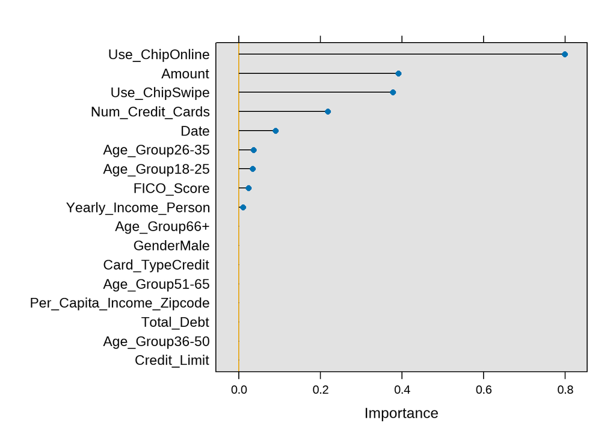

```r
lr_imp <- varImp(lrFit, scale = F)
plot(lr_imp, scales = list(y = list(cex = .95)))
```

The variable importance analysis from the glmnet penalized logistic regression model identifies “Use_ChipOnline” as the most influential variable, with a substantial importance score of 0.798080. This suggests that the method of transaction (online or not) significantly impacts the model’s predictions. “Amount” and “Use_ChipSwipe” also exhibit high importance scores, emphasizing the importance of transaction amount and chip usage. “Num_Credit_Cards” and various age groups, such as “Age_Group26-35”,also contribute significantly. These insights provide a valuable understanding of the key drivers influencing the logistic regression model’s predictions.

#### 4.1.1.2 The ROC curve to improve the model.

A ROC curve is a graph showing the performance of a classification model at all classification thresholds. This curve plots two parameters:

```
- 1. True Positive Rate in the y-axis.
- 2. False Positive Rate in the x-axis.
```

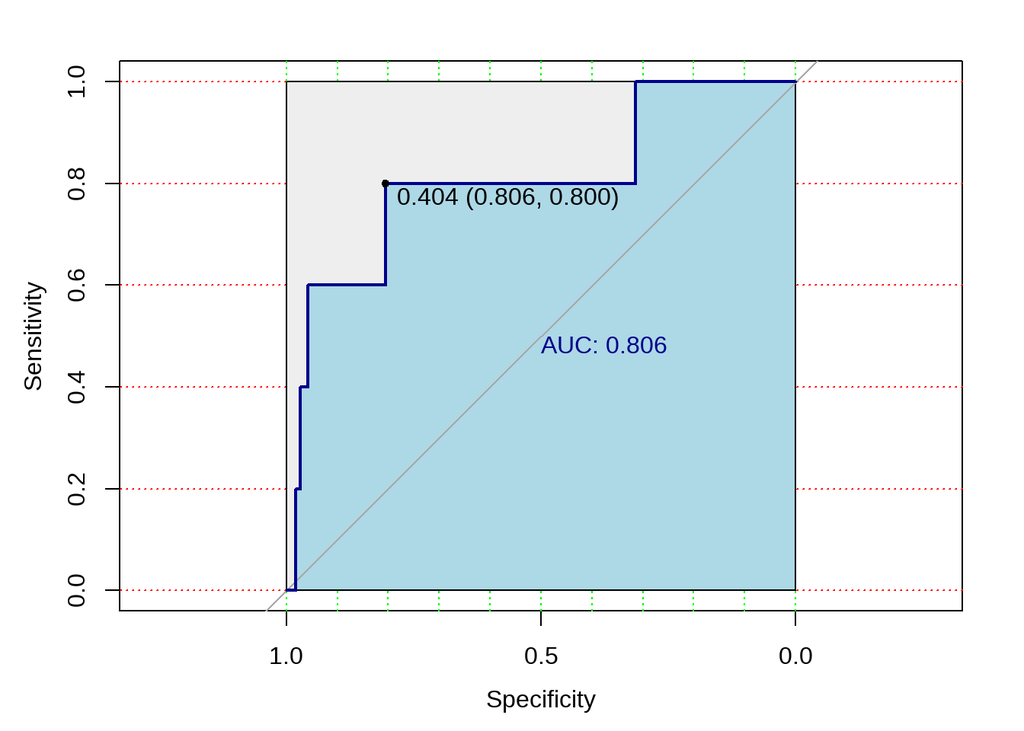

```r
lrProb = predict(lrFit, sampled_test_set_class, type="prob")

plot.roc(sampled_test_set_class$Fraud, lrProb[,2],col="darkblue", print.auc = TRUE,  auc.polygon=TRUE, grid=c(0.1, 0.2),
         grid.col=c("green", "red"), max.auc.polygon=TRUE,
         auc.polygon.col="lightblue", print.thres=TRUE)
```

The ROC plotted curve indicates that the logistic regression model has an AUC (Area Under the Curve) value of 0.806. This value summarizes the model’s performance across various classification thresholds. An AUC value closer to 1 indicates better discriminative ability.

Using the provided threshold, the model was adjusted to establish a balance between sensitivity-specificity.

```r
# Set the threshold
threshold = 0.404

# Predict probabilities using the logistic regression model
lrProb = predict(lrFit, sampled_test_set_class, type="prob")

#sampled_test_set_class <- head(sampled_test_set_class, -1)

# Initialize predictions as "No"
lrPred = rep("No", nrow(sampled_test_set_class))

# Update predictions based on the specified threshold
lrPred[which(lrProb[,2] > threshold)] = "Yes"

# Calculate the confusion matrix
cm2 <- confusionMatrix(factor(lrPred), sampled_test_set_class$Fraud, positive = "Yes")
print(cm2)
```

```
## Confusion Matrix and Statistics
##
##           Reference
## Prediction   No  Yes
##        No  2365    1
##        Yes  573    4
##
##                Accuracy : 0.805
##                  95% CI : (0.7902, 0.8191)
##     No Information Rate : 0.9983
##     P-Value [Acc > NIR] : 1
##
##                   Kappa : 0.0104
##
##  Mcnemar's Test P-Value : <2e-16
##
##             Sensitivity : 0.800000
##             Specificity : 0.804969
##          Pos Pred Value : 0.006932
##          Neg Pred Value : 0.999577
##              Prevalence : 0.001699
##          Detection Rate : 0.001359
##    Detection Prevalence : 0.196058
##       Balanced Accuracy : 0.802485
##
##        'Positive' Class : Yes
##
```

In the context of fraud detection, achieving a balance between sensitivity and specificity is crucial. Sensitivity represents the ability to correctly identify fraudulent transactions. With a Sensitivity of 80% and Specificity of 80.5%, it seems to be a good model.

## 4.2 Machine Lerning Tools for Classification

### 4.2.1 Decision Trees

Decision trees are a powerful machine learning tool commonly used for both classification and regression tasks. They work by recursively partitioning the data into subsets based on the values of different features, ultimately leading to a tree-like structure where each leaf node represents a class label (in the case of classification) or a predicted value (in the case of regression).

**Step 1: Set Hyperparameters for Decision Tree Model**

In the initial phase of building our fraud detection model using a decision tree, we set specific hyperparameters to guide the training process. Hyperparameters are configuration settings that influence the behavior of the machine learning algorithm. For our decision tree model, we carefully selected hyperparameters to strike a balance between model complexity and generalization to new, unseen data.

```r
# Hyper-parameters
control = rpart.control(minsplit = 30, maxdepth = 10, cp=0.01)
```

**Step 2: Building the Decision Tree Model**

The next step in our fraud detection project involves constructing a decision tree model. The model is trained on the sampled training dataset (sampled_train_set_class) using the rpart function. The formula Fraud ~ . indicates that we are predicting the “Fraud” variable using all other available features. The method = “class” argument specifies that this is a classification problem.

```r
set.seed(123)
model = Fraud ~.
dtFit <- rpart(model, data=sampled_train_set_class, method = "class", control = control)
summary(dtFit)
```

```
## Call:
## rpart(formula = model, data = sampled_train_set_class, method = "class",
##     control = control)
##   n= 9672
##
##           CP nsplit rel error    xerror        xstd
## 1 0.48747105      0 1.0000000 1.0000000 0.010352749
## 2 0.02800590      1 0.5125290 0.5125290 0.008986887
## 3 0.02295220      2 0.4845231 0.4908402 0.008857037
## 4 0.02232049      3 0.4615709 0.4857865 0.008825714
## 5 0.01526637      4 0.4392504 0.4373552 0.008503972
## 6 0.01000000      6 0.4087176 0.4194567 0.008374617
##
## Variable importance
## Use_Chip     Date   Amount
##       61       28       11
##
## Node number 1: 9672 observations,    complexity param=0.487471
##   predicted class=No   expected loss=0.491005  P(node) =1
##     class counts:  4923  4749
##    probabilities: 0.509 0.491
##   left son=2 (6199 obs) right son=3 (3473 obs)
##   Primary splits:
##       Use_Chip         splits as  LLR,          improve=1269.67800, (0 missing)
##       Amount           < 100.475  to the left,  improve= 507.48600, (0 missing)
##       Num_Credit_Cards < 2.5      to the left,  improve=  75.97044, (0 missing)
##       Date             < 18195.5  to the right, improve=  62.05058, (0 missing)
##       Age_Group        splits as  LLLRRR,       improve=  24.96144, (0 missing)
##   Surrogate splits:
##       Amount    < 120.565  to the left,  agree=0.683, adj=0.117, (0 split)
##       Age_Group splits as  RLLLLL,       agree=0.641, adj=0.000, (0 split)
##
## Node number 2: 6199 observations,    complexity param=0.0229522
##   predicted class=No   expected loss=0.2992418  P(node) =0.6409222
##     class counts:  4344  1855
##    probabilities: 0.701 0.299
##   left son=4 (4792 obs) right son=5 (1407 obs)
##   Primary splits:
##       Date             < 17495    to the left,  improve=208.79250, (0 missing)
##       Amount           < 144.95   to the left,  improve=166.44680, (0 missing)
```

[output cut: 83 more lines]

```
##
## Node number 11: 1301 observations
##   predicted class=Yes  expected loss=0.4173713  P(node) =0.134512
##     class counts:   543   758
##    probabilities: 0.417 0.583
##
## Node number 18: 1571 observations
##   predicted class=No   expected loss=0.3182686  P(node) =0.1624276
##     class counts:  1071   500
##    probabilities: 0.682 0.318
##
## Node number 19: 291 observations
##   predicted class=Yes  expected loss=0.2508591  P(node) =0.03008685
##     class counts:    73   218
##    probabilities: 0.251 0.749
```

Better interpretation with visualization

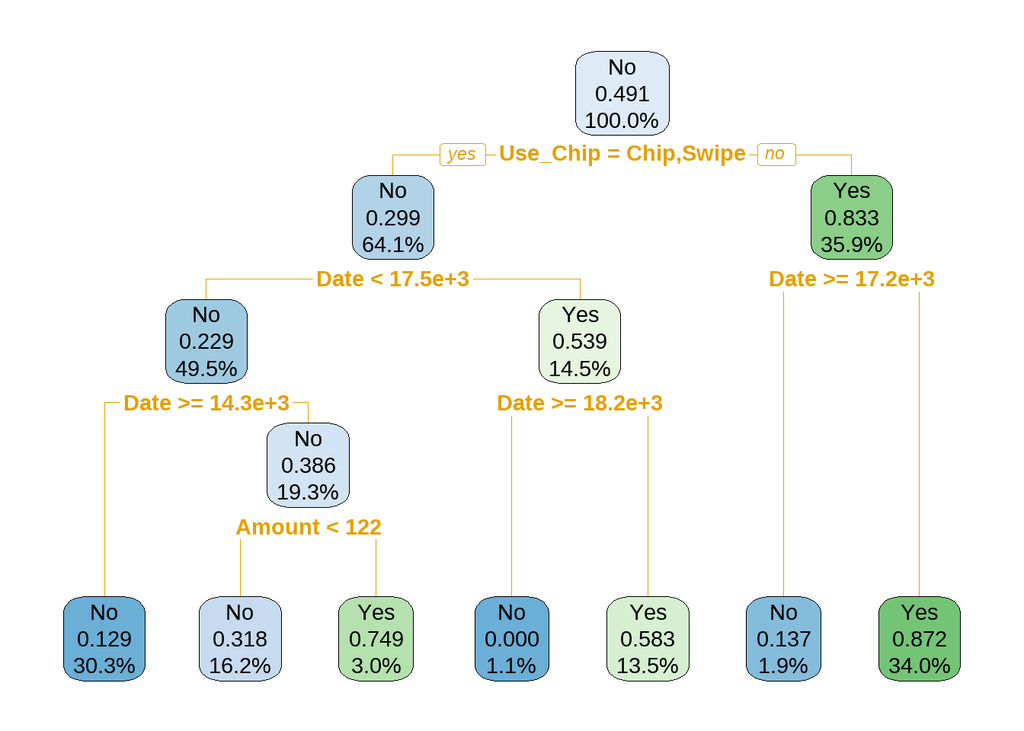

```r
rpart.plot(dtFit, digits=3)
```

In constructing our decision tree model using the CART algorithm, the most influential variables are identified based on variable importance analysis. According to the model, the primary factors contributing to the classification of transactions are Use_Chip, Amount, and Date, with Use_Chip being the most crucial. This variable importance ranking suggests that the presence or absence of chip usage in a transaction holds significant discriminatory power in predicting fraud.

The leaves of the tree represent the predicted outcomes (“No” or “Yes” for fraud), providing a clear path of decision-making.

**Step 3: Prediction**

```r
# Assuming you have the levels defined for "Age_Group" in your training set
age_levels <- levels(sampled_train_set_class$Age_Group)

# Ensure the same levels in the test set to avoid errors
sampled_test_set_class$Age_Group <- factor(sampled_test_set_class$Age_Group, levels = age_levels)

dtPred <- predict(dtFit, sampled_test_set_class, type = "class")

cm_dt1 = confusionMatrix(factor(dtPred), sampled_test_set_class$Fraud, positive = "Yes")
cm_dt1
```

```
## Confusion Matrix and Statistics
##
##           Reference
## Prediction   No  Yes
##        No  2254    1
##        Yes  684    4
##
##                Accuracy : 0.7672
##                  95% CI : (0.7515, 0.7824)
##     No Information Rate : 0.9983
##     P-Value [Acc > NIR] : 1
##
##                   Kappa : 0.0082
##
##  Mcnemar's Test P-Value : <2e-16
##
##             Sensitivity : 0.800000
##             Specificity : 0.767189
##          Pos Pred Value : 0.005814
##          Neg Pred Value : 0.999557
##              Prevalence : 0.001699
##          Detection Rate : 0.001359
##    Detection Prevalence : 0.233775
##       Balanced Accuracy : 0.783594
##
##        'Positive' Class : Yes
##
```

The decision tree model achieved an overall accuracy of 76.72%, with a 95% confidence interval between 75.15% and 78.24%. However,the specificity (true negative rate) is not ver high at 76.72%, suggesting a not very good ability to correctly identify negative cases. On the other hand, the sensitivity (true positive rate) is relatively high at 80%, indicating that the model identified a good portion of the actual positive cases.

In summary, while the decision tree model shows good sensitivity, it struggles with specificity. This suggests that the model may benefit from further tuning or alternative approaches to improve its performance in detecting fraudulent transactions.

#### 4.2.1.1 Cross-Validation for tunning Hyperparameters

```r
set.seed(123)
# Example: Optimize based on sensitivity with positive class = Yes
# Example: Optimize based on sensitivity with positive class = "Yes"
ctrl <- trainControl(method = "cv", number = 5, summaryFunction = twoClassSummary, classProbs = TRUE)

caret.fit <- train(Fraud ~ .,
                   data = sampled_train_set_class,
                   method = "rpart",
                   control = rpart.control(minsplit = 40, maxdepth = 12),
                   trControl = ctrl,
                   tuneLength = 10,
                   metric = "Sens")


caret.fit
```

```
## CART
##
## 9672 samples
##   12 predictor
##    2 classes: 'No', 'Yes'
##
## No pre-processing
## Resampling: Cross-Validated (5 fold)
## Summary of sample sizes: 7737, 7739, 7737, 7738, 7737
## Resampling results across tuning parameters:
##
##   cp           ROC        Sens       Spec
##   0.001824946  0.8646939  0.7814339  0.8328062
##   0.002316277  0.8600571  0.7712812  0.8408059
##   0.002737418  0.8600030  0.7722958  0.8384908
##   0.003895557  0.8461127  0.7901698  0.8102743
##   0.004632554  0.8457233  0.7879363  0.8104848
##   0.015266372  0.8256405  0.7824592  0.7923651
##   0.022320489  0.8006401  0.8025583  0.7359441
##   0.022952200  0.8006401  0.8025583  0.7359441
##   0.028005896  0.7587935  0.8651401  0.6365442
##   0.487471047  0.6418138  0.9270835  0.3565442
##
## Sens was used to select the optimal model using the largest value.
## The final value used for the model was cp = 0.487471.
```

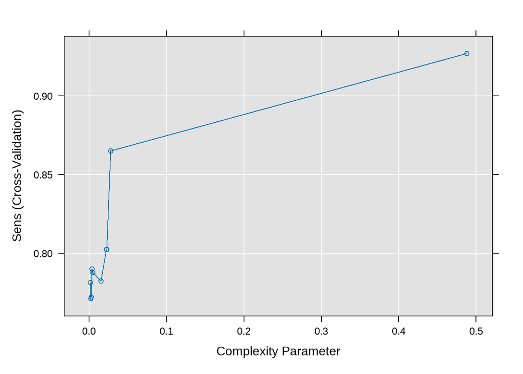

```r
plot(caret.fit)
```

Now, let’s observe the predictions:

```r
dt_pred <- predict(caret.fit, sampled_test_set_class)
# Refactor levels of dt_pred to match those of sampled_test_set_class$Fraud
dt_pred <- factor(dt_pred, levels = levels(sampled_test_set_class$Fraud))

cm_dt2 <- confusionMatrix(dt_pred, sampled_test_set_class$Fraud, positive = "Yes")
cm_dt2
```

```
## Confusion Matrix and Statistics
##
##           Reference
## Prediction   No  Yes
##        No  2938    5
##        Yes    0    0
##
##                Accuracy : 0.9983
##                  95% CI : (0.996, 0.9994)
##     No Information Rate : 0.9983
##     P-Value [Acc > NIR] : 0.61596
##
##                   Kappa : 0
##
##  Mcnemar's Test P-Value : 0.07364
##
##             Sensitivity : 0.000000
##             Specificity : 1.000000
##          Pos Pred Value :      NaN
##          Neg Pred Value : 0.998301
##              Prevalence : 0.001699
##          Detection Rate : 0.000000
##    Detection Prevalence : 0.000000
##       Balanced Accuracy : 0.500000
##
##        'Positive' Class : Yes
##
```

Not good at all

```r
dt_pred <- predict(caret.fit, sampled_test_set_class, type = "prob")
threshold <- 0.4
dtPred <- ifelse(dt_pred[, "Yes"] > threshold, "Yes", "No")
dtPred <- factor(dtPred, levels = levels(sampled_test_set_class$Fraud))


cm_dt_adjusted <- confusionMatrix(factor(dtPred), sampled_test_set_class$Fraud, positive = "Yes")

cm_dt_adjusted
```

```
## Confusion Matrix and Statistics
##
##           Reference
## Prediction   No  Yes
##        No     0    0
##        Yes 2938    5
##
##                Accuracy : 0.0017
##                  95% CI : (6e-04, 0.004)
##     No Information Rate : 0.9983
##     P-Value [Acc > NIR] : 1
##
##                   Kappa : 0
##
##  Mcnemar's Test P-Value : <2e-16
##
##             Sensitivity : 1.000000
##             Specificity : 0.000000
##          Pos Pred Value : 0.001699
##          Neg Pred Value :      NaN
##              Prevalence : 0.001699
##          Detection Rate : 0.001699
##    Detection Prevalence : 1.000000
##       Balanced Accuracy : 0.500000
##
##        'Positive' Class : Yes
##
```

Despite efforts to optimize the threshold for sensitivity, the decision tree model, as evaluated through caret and threshold adjustment, exhibits significant limitations, particularly in terms of specificity. The model struggles to correctly identify negative cases, leading to a high number of false positives. This deficiency is indicative of a poor overall model performance, as it compromises the ability to distinguish between fraudulent and non-fraudulent transactions effectively. In practical terms, this signifies that the model lacks the necessary precision and accuracy required for reliable fraud detection. Further refinement or exploration of alternative modeling approaches may be necessary to address these shortcomings and enhance the model’s effectiveness in real-world applications.

### 4.2.2 Random Forest

The random forest model is being trained on the sampled training set, utilizing 200 decision trees (ntree=200). The mtry=10 parameter specifies the number of randomly selected predictors at each split, contributing to the diversity of the individual trees. The importance=TRUE setting allows the model to calculate variable importance measures, providing insights into the significance of each predictor. Additionally, the do.trace=T option enables the tracking of the training process, allowing for the monitoring of the model’s progression. This ensemble learning approach is expected to enhance predictive accuracy and robustness by leveraging the collective knowledge of multiple decision trees.

```r
set.seed(123)
rf.train <- randomForest(Fraud ~., data=sampled_train_set_class, ntree=200, mtry=10, importance=TRUE, do.trace=T)
```

```
## ntree      OOB      1      2
##     1:  23.13% 23.99% 22.21%
##     2:  23.15% 23.30% 22.99%
##     3:  22.36% 21.62% 23.12%
##     4:  22.30% 21.68% 22.93%
##     5:  22.03% 20.87% 23.22%
##     6:  21.84% 20.73% 23.00%
##     7:  20.91% 20.01% 21.84%
##     8:  20.42% 19.04% 21.86%
##     9:  20.25% 19.22% 21.31%
##    10:  19.55% 18.60% 20.55%
##    11:  19.05% 18.22% 19.90%
##    12:  18.77% 18.02% 19.54%
##    13:  18.47% 17.63% 19.34%
##    14:  18.48% 17.67% 19.32%
```

[output cut: 186 more lines]

**Prediction**

```r
rf.pred <- predict(rf.train, newdata=sampled_test_set_class)
cm_rf = confusionMatrix(rf.pred, sampled_test_set_class$Fraud, positive = "Yes")
cm_rf
```

```
## Confusion Matrix and Statistics
##
##           Reference
## Prediction   No  Yes
##        No  2495    0
##        Yes  443    5
##
##                Accuracy : 0.8495
##                  95% CI : (0.836, 0.8622)
##     No Information Rate : 0.9983
##     P-Value [Acc > NIR] : 1
##
##                   Kappa : 0.0188
##
##  Mcnemar's Test P-Value : <2e-16
##
##             Sensitivity : 1.000000
##             Specificity : 0.849217
##          Pos Pred Value : 0.011161
##          Neg Pred Value : 1.000000
##              Prevalence : 0.001699
##          Detection Rate : 0.001699
##    Detection Prevalence : 0.152226
##       Balanced Accuracy : 0.924609
##
##        'Positive' Class : Yes
##
```

#### 4.2.2.1 Cross-Validation for tunning Hyperparameters

```r
set.seed(123)
# Let's obtain a new model changing the hyperparameters.
rf.train <- train(Fraud ~.,
                  method = "rf",
                  data = sampled_train_set_class,
                  preProcess = c("center", "scale"),
                  ntree = 200,
                  tuneGrid = expand.grid(mtry=c(6,8,10)),
                  trControl = trainControl(method = "cv", number = 5))

# Finally, it is time to predict our model and  check the effectiveness using
# the confusion matrix (check above for further explanations).
rf.train$results
```

```
##   mtry  Accuracy     Kappa  AccuracySD    KappaSD
## 1    6 0.8451202 0.6900432 0.006679271 0.01346912
## 2    8 0.8436728 0.6871951 0.006462796 0.01298662
## 3   10 0.8453268 0.6905343 0.007051882 0.01417467
```

```r
rf.train
```

```
## Random Forest
##
## 9672 samples
##   12 predictor
##    2 classes: 'No', 'Yes'
##
## Pre-processing: centered (17), scaled (17)
## Resampling: Cross-Validated (5 fold)
## Summary of sample sizes: 7737, 7739, 7737, 7738, 7737
## Resampling results across tuning parameters:
##
##   mtry  Accuracy   Kappa
##    6    0.8451202  0.6900432
##    8    0.8436728  0.6871951
##   10    0.8453268  0.6905343
##
## Accuracy was used to select the optimal model using the largest value.
## The final value used for the model was mtry = 10.
```

**Prediction**

```r
rfPred = predict(rf.train, newdata=sampled_test_set_class)
cm_rf2 <- confusionMatrix(factor(rfPred), sampled_test_set_class$Fraud, positive = "Yes")
cm_rf2
```

```
## Confusion Matrix and Statistics
##
##           Reference
## Prediction   No  Yes
##        No  2514    0
##        Yes  424    5
##
##                Accuracy : 0.8559
##                  95% CI : (0.8427, 0.8684)
##     No Information Rate : 0.9983
##     P-Value [Acc > NIR] : 1
##
##                   Kappa : 0.0197
##
##  Mcnemar's Test P-Value : <2e-16
##
##             Sensitivity : 1.000000
##             Specificity : 0.855684
##          Pos Pred Value : 0.011655
##          Neg Pred Value : 1.000000
##              Prevalence : 0.001699
##          Detection Rate : 0.001699
##    Detection Prevalence : 0.145770
##       Balanced Accuracy : 0.927842
##
##        'Positive' Class : Yes
##
```

The confusion matrix for the random forest CV model indicates promising results. The model achieved an accuracy of approximately 85.6%, with a sensitivity of 100% and specificity of 85.57%. The high sensitivity suggests that the model effectively identifies instances of fraudulent transactions, while the specificity demonstrates a notable ability to correctly classify non-fraudulent transactions.

### 4.2.3 Gradient Boosting

```r
# Assuming Date is in a date format, convert it to numeric
set.seed(123)
sampled_train_set_class$Date <- as.numeric(sampled_train_set_class$Date)


GBM.train <- gbm(ifelse(sampled_train_set_class$Fraud=="No",0,1) ~.,
                 data=sampled_train_set_class,
                 distribution= "bernoulli",
                 n.trees=250,
                 shrinkage = 0.01,
                 interaction.depth=2,
                 n.minobsinnode = 8)
```

**Prediction**

```r
# Assuming Date is in a date format, convert it to numeric for the test set
sampled_test_set_class$Date <- as.numeric(sampled_test_set_class$Date)

# Make predictions on the test set
GBM.pred <- predict(GBM.train, newdata = sampled_test_set_class, n.trees = 250, type = "response")

# Convert the probabilities to binary predictions using a threshold (e.g., 0.5)
threshold <- 0.5
GBM.binary_pred <- ifelse(GBM.pred > threshold, "Yes", "No")

# Create a confusion matrix
cm_gbm1 <- confusionMatrix(factor(GBM.binary_pred), sampled_test_set_class$Fraud, positive = "Yes")

# Print the confusion matrix and statistics
cm_gbm1
```

```
## Confusion Matrix and Statistics
##
##           Reference
## Prediction   No  Yes
##        No  2572    0
##        Yes  366    5
##
##                Accuracy : 0.8756
##                  95% CI : (0.8632, 0.8874)
##     No Information Rate : 0.9983
##     P-Value [Acc > NIR] : 1
##
##                   Kappa : 0.0233
##
##  Mcnemar's Test P-Value : <2e-16
##
##             Sensitivity : 1.000000
##             Specificity : 0.875425
##          Pos Pred Value : 0.013477
##          Neg Pred Value : 1.000000
##              Prevalence : 0.001699
##          Detection Rate : 0.001699
##    Detection Prevalence : 0.126062
##       Balanced Accuracy : 0.937713
##
##        'Positive' Class : Yes
##
```

## 4.3 Model Selection

```r
results_class <- rbind(
  c("PENALIZED LOGISTIC REGRESSION 1:", cm$overall["Accuracy"], cm$byClass["Sensitivity"], cm$byClass["Specificity"]),
  c("PENALIZED LOGISTIC REGRESSION 2:", cm2$overall["Accuracy"], cm2$byClass["Sensitivity"], cm2$byClass["Specificity"]),
  c("DECISION TREES (OPTION 1)", cm_dt1$overall["Accuracy"], cm_dt1$byClass["Sensitivity"], cm_dt1$byClass["Specificity"]),
  c("DECISION TREES (CV 1)", cm_dt2$overall["Accuracy"], cm_dt2$byClass["Sensitivity"], cm_dt2$byClass["Specificity"]),
  c("DECISION TREES (CV 2)", cm_dt_adjusted$overall["Accuracy"], cm_dt_adjusted$byClass["Sensitivity"], cm_dt_adjusted$byClass["Specificity"]),
  c("RANDOM FORESTS TREES (OPTION 1)", cm_rf$overall["Accuracy"], cm_rf$byClass["Sensitivity"], cm_rf$byClass["Specificity"]),
  c("RANDOM FORESTS (CV)", cm_rf2$overall["Accuracy"], cm_rf2$byClass["Sensitivity"], cm_rf2$byClass["Specificity"]),
  c("GRADIENT BOOSTING ", cm_gbm1$overall["Accuracy"], cm_gbm1$byClass["Sensitivity"], cm_gbm1$byClass["Specificity"])
)

colnames(results_class) <- c("Model", "Accuracy", "Sensitivity", "Specificity")
```

```r
# Convert results_class to a data frame
results_df <- as.data.frame(results_class, stringsAsFactors = FALSE)

# Print the table
knitr::kable(results_df, format = "markdown")
```

| Model | Accuracy | Sensitivity | Specificity |
| --- | --- | --- | --- |
| PENALIZED LOGISTIC REGRESSION 1: | 0.885151206252124 | 0.6 | 0.885636487406399 |
| PENALIZED LOGISTIC REGRESSION 2: | 0.804960924226979 | 0.8 | 0.80496936691627 |
| DECISION TREES (OPTION 1) | 0.767244308528712 | 0.8 | 0.767188563648741 |
| DECISION TREES (CV 1) | 0.998301053346925 | 0 | 1 |
| DECISION TREES (CV 2) | 0.00169894665307509 | 1 | 0 |
| RANDOM FORESTS TREES (OPTION 1) | 0.849473326537547 | 1 | 0.849217154526889 |
| RANDOM FORESTS (CV) | 0.855929323819232 | 1 | 0.85568413886998 |
| GRADIENT BOOSTING | 0.875637104994903 | 1 | 0.875425459496256 |

The model selection process underscored the importance of considering not only accuracy but also sensitivity and specificity in the context of fraud detection. GRADIENT BOOSTING’s superior performance metrics positioned it as the optimal choice, emphasizing the significance of leveraging advanced machine learning techniques in scenarios where achieving a delicate balance between sensitivity and specificity is paramount. This selection aligns with the project’s overarching goal of implementing a robust and accurate fraud detection system that minimizes both false positives and false negatives, thereby enhancing the efficiency of fraud identification within the given dataset.

## 4.4 Conclusion of Classification

In the pursuit of developing an effective fraud detection system, the project encountered various challenges, including the management of extensive datasets and addressing the complexities posed by imbalanced classes. It adeptly navigated these hurdles by strategically sampling data and implementing a variation of undersampling techniques to balance the class distribution. The size of the datasets presented computational challenges, leading to the adoption of efficient strategies to accelerate the project’s pace.

The project followed a systematic workflow that began with extensive preprocessing, encompassing data cleaning, feature engineering, and scaling. Data exploration and visualization were pivotal in gaining insights into the dataset’s characteristics. A combination of statistical and machine learning tools was employed to uncover patterns, relationships, and potential features for classification. The iterative process involved tuning hyperparameters, selecting models, and optimizing performance to achieve the desired results.

Despite the intricacies of the task, Gradient Boosting emerged as the most adept solution for fraud detection. This model, characterized by a high accuracy of 87.56%, perfect sensitivity, and a specificity of 87.54%, demonstrated a remarkable ability to detect fraudulent transactions while minimizing false positives. The comprehensive approach taken in this project, from data exploration to model selection, underscores the significance of a well-structured methodology in the realm of fraud detection. The robustness of the chosen model, Gradient Boosting, and the insights gained from this process collectively contribute to a powerful and practical fraud detection system with real-world applicability.

# 5 REGRESSION

## 5.1 Intro: Predicting Transaction Amounts as a Window into Risk

Complementing the classification task, our regression focus delves into predicting transaction amounts, a critical dimension that adds granularity to our fraud detection system. This predictive lens offers insights into transaction anomalies, with a specific emphasis on understanding and assessing the risk associated with varying transaction sizes.

Why is this Useful?

- Anomaly Identification: Predicting transaction amounts aids in identifying anomalous patterns or irregularities in transaction sizes, a key indicator of potential fraud.
- Dynamic Risk Assessment: Continuous prediction allows our system to dynamically adapt to emerging fraud dynamics, ensuring a proactive stance against evolving fraudulent activities.
- User-Centric Analysis: A deeper understanding of user-specific transaction amounts allows for nuanced anomaly detection, tailoring our approach to individual spending behaviors.

## 5.2 Visualization

Again, let’s import the datasets.

```r
sampled_train_set_class <- read.csv("sampled_train_set_class.csv")
sampled_test_set_class <- read.csv("sampled_test_set_class.csv")
```

We need to repeat some preprocessing steps, as when importing the datasets, some of the features are converted to “chr” again.

```r
### Use_Chip
sampled_train_set_class$Use_Chip= factor(x = sampled_train_set_class$Use_Chip,
                                  levels = c("Chip", "Swipe", "Online"),
                                  labels =  c("Chip", "Swipe", "Online")
                                  )

sampled_test_set_class$Use_Chip= factor(x = sampled_test_set_class$Use_Chip,
                                  levels = c("Chip", "Swipe", "Online"),
                                  labels =  c("Chip", "Swipe", "Online")
                                  )


### Card_Type
sampled_train_set_class$Card_Type = factor(x = sampled_train_set_class$Card_Type,
                                    levels = c("Debit", "Credit"),
                                   labels = c("Debit", "Credit")
                                   )

sampled_test_set_class$Card_Type = factor(x = sampled_test_set_class$Card_Type,
                                    levels = c("Debit", "Credit"),
                                   labels = c("Debit", "Credit")
                                   )




### Gender
sampled_train_set_class$Gender = factor(x = sampled_train_set_class$Gender,
                                levels = c("Female", "Male"),
                                labels = c("Female", "Male") )

sampled_test_set_class$Gender = factor(x = sampled_test_set_class$Gender,
                                levels = c("Female", "Male"),
                                labels = c("Female", "Male") )



### Merchant_City
sampled_train_set_class$Merchant_City = as.factor(sampled_train_set_class$Merchant_City)
sampled_test_set_class$Merchant_City = as.factor(sampled_test_set_class$Merchant_City)



### City
sampled_train_set_class$City = as.factor(sampled_train_set_class$City)
sampled_test_set_class$City = as.factor(sampled_test_set_class$City)

### State
sampled_train_set_class$State = as.factor(sampled_train_set_class$State)
sampled_test_set_class$State = as.factor(sampled_test_set_class$State)

# Assuming that Year, Month, and Day are already numeric
sampled_train_set_class$Date <- as.Date(sampled_train_set_class$Date)
sampled_test_set_class$Date <- as.Date(sampled_test_set_class$Date)


sampled_train_set_class$Age_Group = as.factor(sampled_train_set_class$Age_Group)
sampled_test_set_class$Age_Group = as.factor(sampled_test_set_class$Age_Group)
```

For this task, Fraud variable is going to be removed. The model can then focus on learning patterns related to transaction amounts that are not biased by the binary fraud label.

```r
sampled_train_set_class =  sampled_train_set_class %>% dplyr::select(-Fraud)
sampled_test_set_class =  sampled_test_set_class %>% dplyr::select(-Fraud)
```

Let’s recover some variables for better predictions in regression

```r
sampled_train_set_no_NAs.csv <- read.csv("sampled_train_set_no_NAs.csv")
sampled_test_set_no_NAs.csv <- read.csv("sampled_test_set_no_NAs.csv")

sampled_train_set_class$Current_Age = sampled_train_set_no_NAs.csv$Current_Age
sampled_test_set_class$Current_Age = sampled_test_set_no_NAs.csv$Current_Age

sampled_train_set_class$Latitude = sampled_train_set_no_NAs.csv$Latitude
sampled_test_set_class$Latitude = sampled_test_set_no_NAs.csv$Latitude

sampled_train_set_class$Longitude = sampled_train_set_no_NAs.csv$Longitude
sampled_test_set_class$Longitude = sampled_test_set_no_NAs.csv$Longitude
```

We have already made visualizations of the amount distribution, we need to remember that they majority fall in the range of (0,250) $

### 5.2.1 Boxplot of Amounts by Categorical Variables

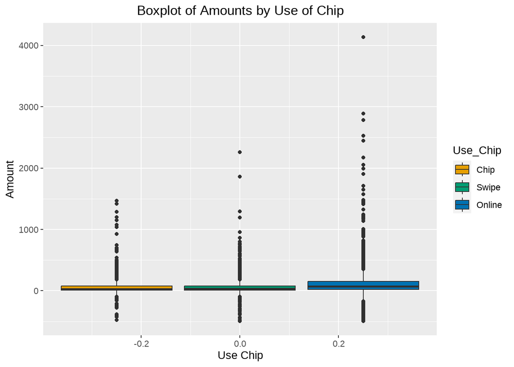

```r
ggplot(sampled_train_set_class, aes(fill = Use_Chip, y = Amount)) +
  geom_boxplot() +
  labs(title = "Boxplot of Amounts by Use of Chip",
       x = "Use Chip", y = "Amount") +
  theme(plot.title = element_text(hjust = 0.5))
```

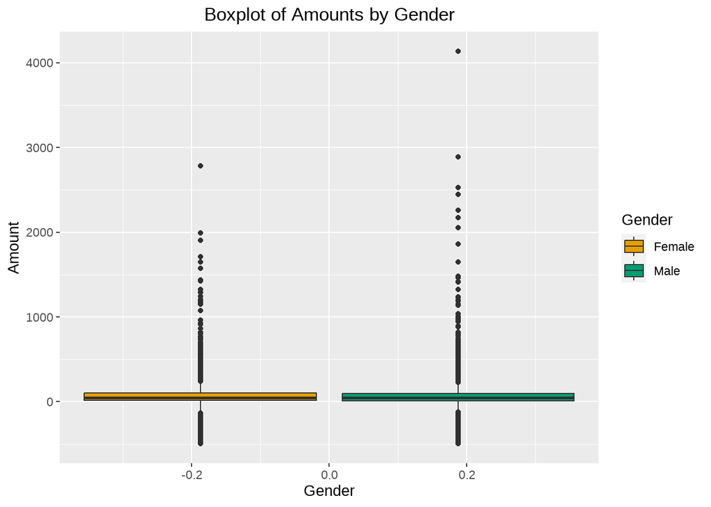

```r
ggplot(sampled_train_set_class, aes(fill = Gender, y = Amount)) +
  geom_boxplot() +
  labs(title = "Boxplot of Amounts by Gender",
       x = "Gender", y = "Amount") +
  theme(plot.title = element_text(hjust = 0.5))
```

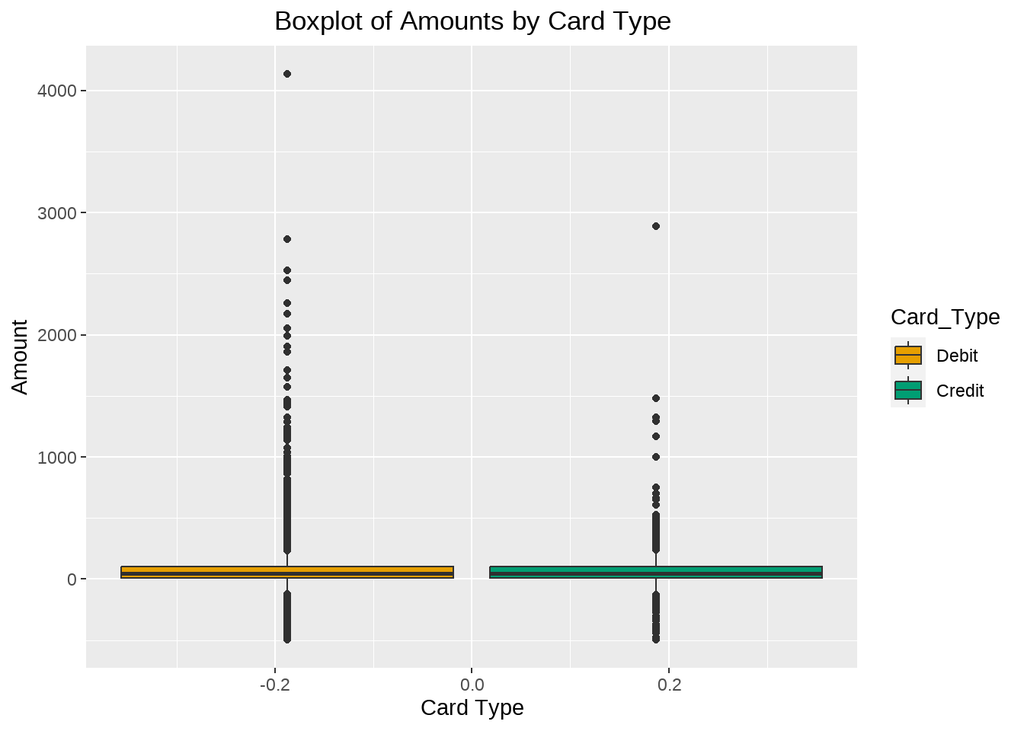

```r
ggplot(sampled_train_set_class, aes(fill = Card_Type, y = Amount)) +
  geom_boxplot() +
  labs(title = "Boxplot of Amounts by Card Type",
       x = "Card Type", y = "Amount") +
  theme(plot.title = element_text(hjust = 0.5))
```

We don’t much difference between the different values for the categorical variables.

**Bar Chart of Amounts by Age Group**

Visualize the average transaction amounts for different age groups. It can be seen that there is not much difference actually

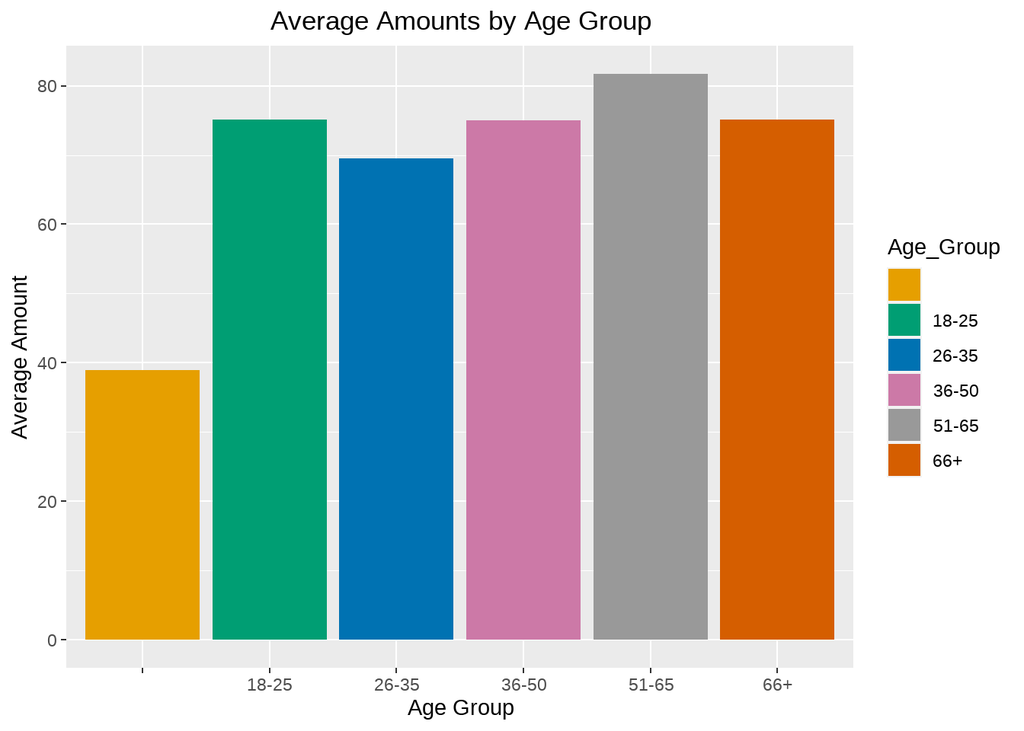

```r
library(ggplot2)
ggplot(sampled_train_set_class, aes(x = Age_Group, y = Amount, fill = Age_Group)) +
  geom_bar(stat = "summary", fun = "mean", position = "dodge") +
  labs(title = "Average Amounts by Age Group", x = "Age Group", y = "Average Amount") +
  theme(plot.title = element_text(hjust = 0.5))
```

**Scatter Plot of Amounts and Credit Limit**

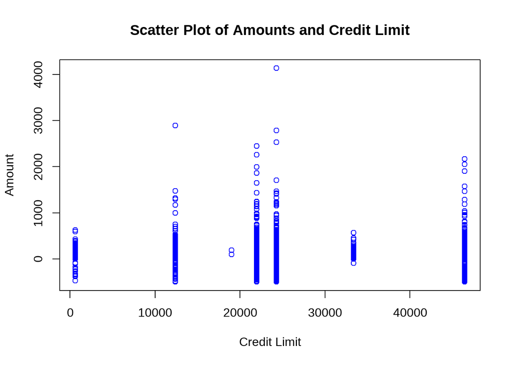

```r
plot(sampled_train_set_class$Credit_Limit, sampled_train_set_class$Amount, main = "Scatter Plot of Amounts and Credit Limit",
     xlab = "Credit Limit", ylab = "Amount", col = "blue") +
  theme(plot.title = element_text(hjust = 0.5))
```

**Time Series Plot of Amounts**

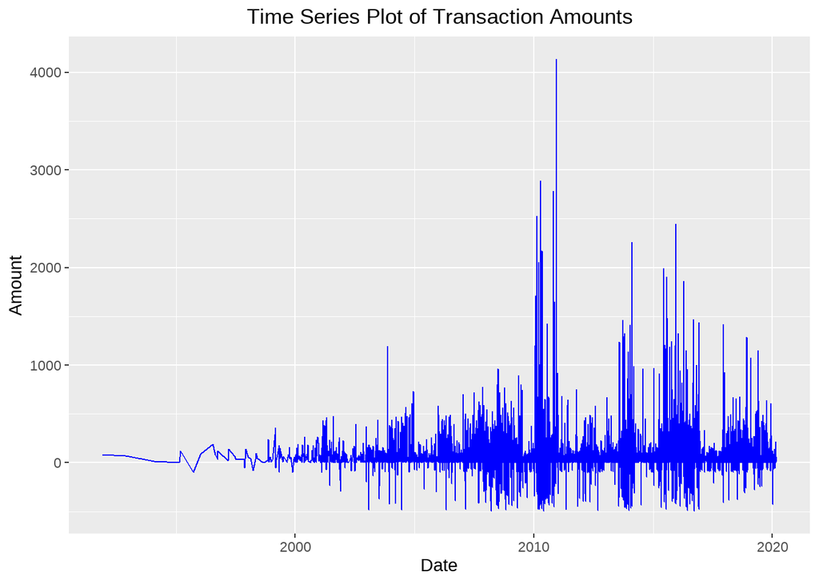

```r
ggplot(sampled_train_set_class, aes(x = Date, y = Amount, group = 1)) +
  geom_line(color = "blue") +
  labs(title = "Time Series Plot of Transaction Amounts", x = "Date", y = "Amount") +
  theme(plot.title = element_text(hjust = 0.5))
```

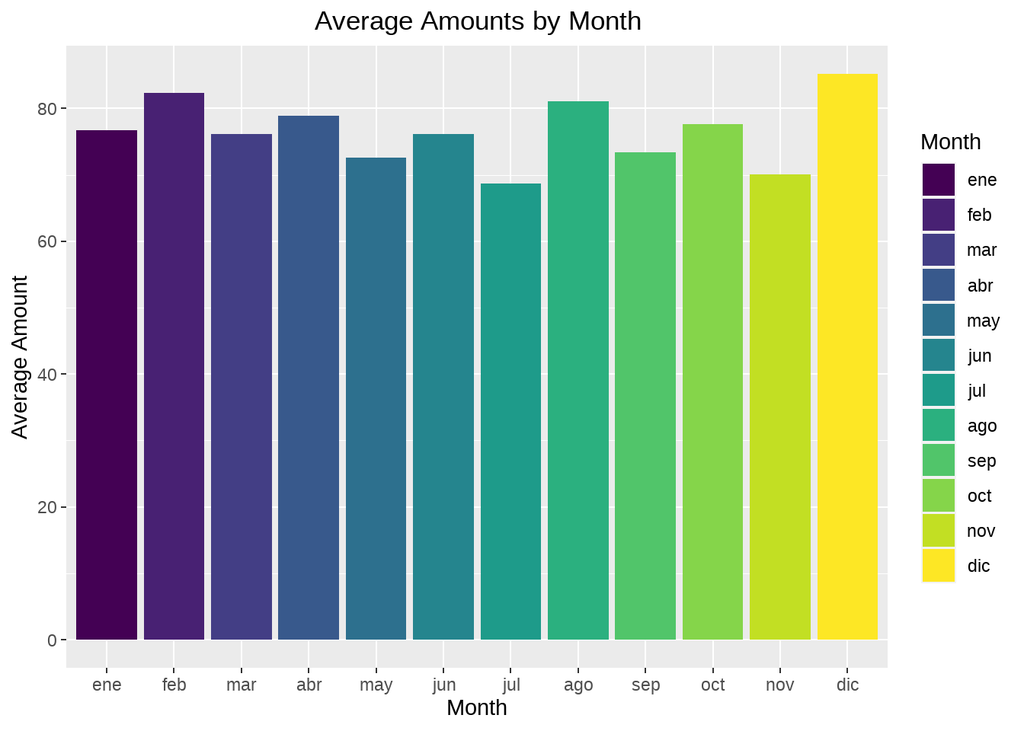

```r
ggplot(sampled_train_set_class, aes(x = factor(month(Date, label = TRUE)), y = Amount, fill = factor(month(Date, label = TRUE)))) +
  geom_bar(stat = "summary", fun = "mean", position = "dodge") +
  labs(title = "Average Amounts by Month", x = "Month", y = "Average Amount", fill = "Month") +
  theme(plot.title = element_text(hjust = 0.5))
```

While observing the average transaction amounts across different months, we note minimal variation. However, a slight increase is evident in December, likely attributed to Christmas-related expenditures, and in August, possibly due to holiday-related expenses

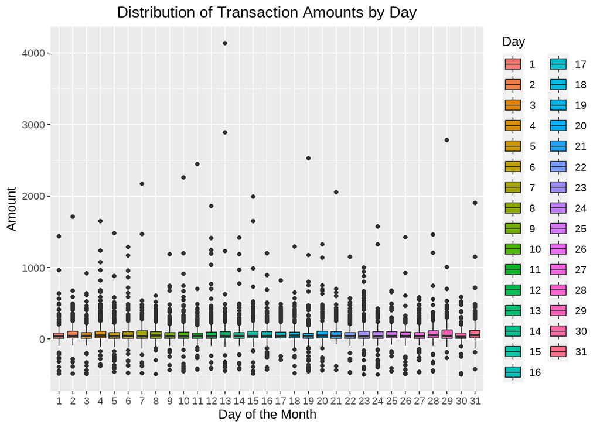

```r
ggplot(sampled_train_set_class, aes(x = factor(day(Date)), y = Amount, fill = factor(day(Date))  )) +
  geom_boxplot() +
  labs(title = "Distribution of Transaction Amounts by Day", x = "Day of the Month", y = "Amount", fill = "Day") +
  theme(plot.title = element_text(hjust = 0.5))
```